# Master Thesis

Weijia Hu

2021-10-05 23:31:37

```r
load("vcomball20210902.Rda")
d <- vcomball
# load("vsurvall20210826.Rda")
# d <- vsurvall

#load("vsiteid20210601.Rda")
```

# Site ID

```r
  siteid <- as.factor(trimws(d[,"siteid"]))
  #new.d.n <- data.frame(new.d.n, siteid) # keep NAACCR coding

  levels(siteid)[levels(siteid)=="80"] <- "Los Angeles County"
  levels(siteid)[levels(siteid)=="30"] <- "Northern CA"
  levels(siteid)[levels(siteid)=="10"] <- "Greater CA"
  levels(siteid)[levels(siteid)=="60"] <- "Detroit"
  levels(siteid)[levels(siteid)=="40"] <- "Louisiana"
  levels(siteid)[levels(siteid)=="20"] <- "Georgia"
  levels(siteid)[levels(siteid)=="61"] <- "Michigan"
  levels(siteid)[levels(siteid)=="50"] <- "New Jersey"
  levels(siteid)[levels(siteid)=="70"] <- "Texas"
  levels(siteid)[levels(siteid)=="99"] <- "WebRecruit"
  levels(siteid)[levels(siteid)=="21"] <- "Georgia"
  levels(siteid)[levels(siteid)=="81"] <- "USC Other"
  levels(siteid)[levels(siteid)=="82"] <- "USC MEC"

  siteid_new<- siteid
  d<-data.frame(d, siteid_new)
  new.d <- data.frame(new.d, siteid)
  new.d <- apply_labels(new.d, siteid = "Site ID")
  temp.d <- data.frame(temp.d, siteid)
```

```r
  siteid_count<-count(new.d$siteid)
  colnames(siteid_count)<- c("Registry", "Total")
  kable(siteid_count, format = "simple", align = 'l', caption = "Overview of all Registries")
```

Overview of all Registries

| Registry | Total |
| --- | --- |
| Greater CA | 282 |
| Georgia | 1575 |
| Northern CA | 201 |
| Louisiana | 563 |
| Detroit | 241 |
| Michigan | 69 |
| Los Angeles County | 334 |

# Y - Outcome variable

- Tumor characteristics
  - PSA level - CS SITE-SPECIFIC FACTOR 1
  - Clinical stage - TNM CLIN T
  - Gleason’s score - CS SITE-SPECIFIC FACTOR 8
- Aggressiveness
  - Low risk
    - PSA < 10
    - Clinical Stage <= T2a
    - Gleason’s score <= 6
  - Intermediate risk
    - 10 < PSA < 20
    - Clinical Stage = T2b
    - Or Gleason’s score = 7
  - High risk
    - PSA >= 20
    - Clinical Stage >= T2c
    - Or Gleason’s score >= 8

## PSA level - CS SITE-SPECIFIC FACTOR 1

- Description: Identifies additional information needed to generate stage, or prognostic factors that have an effect on stage or survival.
- Rationale: Site-specific factors are used to record additional staging information needed by Collaborative Staging to derive TNM and/or SEER Summary Stage codes for particular site-histology schema.
- Codes (The information recorded in CS Site-Specific Factor 1 differs for each anatomic site. See the most current version of the Collaborative Stage Data Collection System (http://cancerstaging.org),13 for rules and site-specific codes and coding structures.)
- Reference: http://datadictionary.naaccr.org/default.aspx?c=10&Version=18#2880
- Reference: http://web2.facs.org/cstage0205/prostate/Prostateschema.html

### All data

```r
st_css() #IMPORTANT!
```

```r
  cssitespecificfactor1 <- trimws(d[,"cssitespecificfactor1"])

  cssitespecificfactor1[which(cssitespecificfactor1=="997")]<-"NA"
  cssitespecificfactor1[which(cssitespecificfactor1=="998")]<-"NA"
  cssitespecificfactor1[which(cssitespecificfactor1=="999")]<-"NA"

  psa<-as.numeric(cssitespecificfactor1)
  psa <- psa/10

  new.d <- data.frame(new.d, psa)
  new.d <- apply_labels(new.d, psa = "PSA level")
  temp.d <- data.frame (temp.d, psa)

  summarytools::view(dfSummary(new.d$psa, style = 'grid', max.distinct.values = 50, plain.ascii = FALSE, valid.col = FALSE, headings = FALSE ), method = "render")
```

**No**

**Variable**

**Label**

**Stats / Values**

**Freqs (% of Valid)**

**Graph**

**Missing**

1

psa [labelled, numeric]

PSA level

| Mean (sd) : 13 (18.1) |
| --- |
| min ≤ med ≤ max: |
| 0.1 ≤ 7 ≤ 98 |
| IQR (CV) : 6.4 (1.4) |

390 distinct values

340 (10.4%)

Generated by summarytools 1.0.0 ([R](https://www.r-project.org/) version 4.0.3)  
2021-10-05

### LA County

**No**

**Variable**

**Stats / Values**

**Freqs (% of Valid)**

**Graph**

**Missing**

1

cs_site_specific_factor1 [numeric]

| Mean (sd) : 14.4 (20) |
| --- |
| min ≤ med ≤ max: |
| 0.1 ≤ 7.6 ≤ 98 |
| IQR (CV) : 7.3 (1.4) |

146 distinct values

18 (5.4%)

Generated by summarytools 1.0.0 ([R](https://www.r-project.org/) version 4.0.3)  
2021-10-05

### Northern CA

**No**

**Variable**

**Stats / Values**

**Freqs (% of Valid)**

**Graph**

**Missing**

1

cs_site_specific_factor1 [numeric]

| Mean (sd) : 12.9 (16.1) |
| --- |
| min ≤ med ≤ max: |
| 0.4 ≤ 7.6 ≤ 98 |
| IQR (CV) : 5.4 (1.2) |

115 distinct values

8 (4.0%)

Generated by summarytools 1.0.0 ([R](https://www.r-project.org/) version 4.0.3)  
2021-10-05

### Greater CA

**No**

**Variable**

**Stats / Values**

**Freqs (% of Valid)**

**Graph**

**Missing**

1

cs_site_specific_factor1 [numeric]

| Mean (sd) : 14 (20.5) |
| --- |
| min ≤ med ≤ max: |
| 0.7 ≤ 7.1 ≤ 98 |
| IQR (CV) : 5.7 (1.5) |

126 distinct values

21 (7.4%)

Generated by summarytools 1.0.0 ([R](https://www.r-project.org/) version 4.0.3)  
2021-10-05

### Detroit

**No**

**Variable**

**Stats / Values**

**Freqs (% of Valid)**

**Graph**

**Missing**

1

cs_site_specific_factor1 [numeric]

| Mean (sd) : 12.7 (18.3) |
| --- |
| min ≤ med ≤ max: |
| 0.5 ≤ 6.5 ≤ 98 |
| IQR (CV) : 5.7 (1.4) |

104 distinct values

65 (27.0%)

Generated by summarytools 1.0.0 ([R](https://www.r-project.org/) version 4.0.3)  
2021-10-05

### Louisiana

**No**

**Variable**

**Stats / Values**

**Freqs (% of Valid)**

**Graph**

**Missing**

1

cs_site_specific_factor1 [numeric]

| Mean (sd) : 12.3 (16.6) |
| --- |
| min ≤ med ≤ max: |
| 0.6 ≤ 6.6 ≤ 98 |
| IQR (CV) : 6.9 (1.4) |

188 distinct values

32 (5.7%)

Generated by summarytools 1.0.0 ([R](https://www.r-project.org/) version 4.0.3)  
2021-10-05

### Georgia

**No**

**Variable**

**Stats / Values**

**Freqs (% of Valid)**

**Graph**

**Missing**

1

cs_site_specific_factor1 [numeric]

| Mean (sd) : 12.7 (17.7) |
| --- |
| min ≤ med ≤ max: |
| 0.4 ≤ 7 ≤ 98 |
| IQR (CV) : 6.3 (1.4) |

279 distinct values

192 (12.2%)

Generated by summarytools 1.0.0 ([R](https://www.r-project.org/) version 4.0.3)  
2021-10-05

### Michigan

**No**

**Variable**

**Stats / Values**

**Freqs (% of Valid)**

**Graph**

**Missing**

1

cs_site_specific_factor1 [numeric]

| Mean (sd) : 15.1 (24.1) |
| --- |
| min ≤ med ≤ max: |
| 0.5 ≤ 6.7 ≤ 98 |
| IQR (CV) : 6.6 (1.6) |

53 distinct values

4 (5.8%)

Generated by summarytools 1.0.0 ([R](https://www.r-project.org/) version 4.0.3)  
2021-10-05

## Clinical stage - TNM CLIN T

- Description: Detailed site-specific codes for the clinical tumor (T) as defined by AJCC and recorded by the physician.
- Pathologic and clinical stage data are given three separate areas in the NAACCR Data Exchange Record Layout.
- Rationale: CoC requires that AJCC TNM staging be used in its approved cancer programs. AJCC developed its staging system for evaluating trends in the treatment and control of cancer. This staging is used by physicians to estimate prognosis, to plan treatment, to evaluate new types of therapy, to analyze outcome, to design follow-up strategies, and to assess early detection results.
- Codes (in addition to those published in the AJCC Cancer Staging Manual)
  - 88 Not applicable, no code assigned for this case in the current AJCC Staging Manual. This field is left blank if no information at all is available to code this item.
- Note: See the AJCC Cancer Staging Manual, current edition for site-specific categories for the TNM elements and stage groups. See the STORE manual for specifications for codes and data entry rules.
- Reference page: http://datadictionary.naaccr.org/default.aspx?c=10&Version=18#940

### All data

```r
# clean tnmclint - remove the first character "c"
  a <- trimws(d[,"tnmclint"])
  for (i in 1:length(a)){
    if (!is.na(a[i])){
    if (substr(a[i],1,1)=="c"){
      a[i]<-substring(a[i],2)
      }
    }
  }

  tnmclint <- as.factor(a)
  levels(tnmclint)[levels(tnmclint)=="88"] <- "Not_applicable.88"

  new.d <- data.frame(new.d, tnmclint)
  new.d <- apply_labels(new.d, tnmclint = "Clinical stage")

  temp.d <- data.frame (temp.d, tnmclint)
  summarytools::view(dfSummary(new.d$tnmclint, style = 'grid', max.distinct.values = 100, plain.ascii = FALSE, valid.col = FALSE, headings = FALSE), method = "render")
```

**No**

**Variable**

**Label**

**Stats / Values**

**Freqs (% of Valid)**

**Graph**

**Missing**

1

tnmclint [labelled, factor]

Clinical stage

| 1. 0 |
| --- |
| 2. 1 |
| 3. 1A |
| 4. 1B |
| 5. 1C |
| 6. 2 |
| 7. 2A |
| 8. 2B |
| 9. 2C |
| 10. 3 |
| 11. 3A |
| 12. 3B |
| 13. 4 |
| 14. X |

| 1 | ( | 0.0% | ) |
| --- | --- | --- | --- |
| 36 | ( | 1.3% | ) |
| 21 | ( | 0.7% | ) |
| 10 | ( | 0.4% | ) |
| 2088 | ( | 73.8% | ) |
| 129 | ( | 4.6% | ) |
| 153 | ( | 5.4% | ) |
| 63 | ( | 2.2% | ) |
| 135 | ( | 4.8% | ) |
| 10 | ( | 0.4% | ) |
| 32 | ( | 1.1% | ) |
| 31 | ( | 1.1% | ) |
| 19 | ( | 0.7% | ) |
| 101 | ( | 3.6% | ) |

436 (13.4%)

Generated by summarytools 1.0.0 ([R](https://www.r-project.org/) version 4.0.3)  
2021-10-05

### LA County

**No**

**Variable**

**Stats / Values**

**Freqs (% of Valid)**

**Graph**

**Missing**

1

cs_site_specific_factor1 [factor]

| 1. 0 |
| --- |
| 2. 1 |
| 3. 1A |
| 4. 1B |
| 5. 1C |
| 6. 2 |
| 7. 2A |
| 8. 2B |
| 9. 2C |
| 10. 3 |
| 11. 3A |
| 12. 3B |
| 13. 4 |
| 14. X |

| 0 | ( | 0.0% | ) |
| --- | --- | --- | --- |
| 3 | ( | 1.2% | ) |
| 1 | ( | 0.4% | ) |
| 0 | ( | 0.0% | ) |
| 184 | ( | 71.3% | ) |
| 10 | ( | 3.9% | ) |
| 19 | ( | 7.4% | ) |
| 7 | ( | 2.7% | ) |
| 21 | ( | 8.1% | ) |
| 0 | ( | 0.0% | ) |
| 0 | ( | 0.0% | ) |
| 3 | ( | 1.2% | ) |
| 3 | ( | 1.2% | ) |
| 7 | ( | 2.7% | ) |

76 (22.8%)

Generated by summarytools 1.0.0 ([R](https://www.r-project.org/) version 4.0.3)  
2021-10-05

### Northern CA

**No**

**Variable**

**Stats / Values**

**Freqs (% of Valid)**

**Graph**

**Missing**

1

cs_site_specific_factor1 [factor]

| 1. 0 |
| --- |
| 2. 1 |
| 3. 1A |
| 4. 1B |
| 5. 1C |
| 6. 2 |
| 7. 2A |
| 8. 2B |
| 9. 2C |
| 10. 3 |
| 11. 3A |
| 12. 3B |
| 13. 4 |
| 14. X |

| 0 | ( | 0.0% | ) |
| --- | --- | --- | --- |
| 1 | ( | 0.6% | ) |
| 1 | ( | 0.6% | ) |
| 1 | ( | 0.6% | ) |
| 118 | ( | 68.6% | ) |
| 2 | ( | 1.2% | ) |
| 21 | ( | 12.2% | ) |
| 6 | ( | 3.5% | ) |
| 12 | ( | 7.0% | ) |
| 1 | ( | 0.6% | ) |
| 4 | ( | 2.3% | ) |
| 1 | ( | 0.6% | ) |
| 3 | ( | 1.7% | ) |
| 1 | ( | 0.6% | ) |

29 (14.4%)

Generated by summarytools 1.0.0 ([R](https://www.r-project.org/) version 4.0.3)  
2021-10-05

### Greater CA

**No**

**Variable**

**Stats / Values**

**Freqs (% of Valid)**

**Graph**

**Missing**

1

cs_site_specific_factor1 [factor]

| 1. 0 |
| --- |
| 2. 1 |
| 3. 1A |
| 4. 1B |
| 5. 1C |
| 6. 2 |
| 7. 2A |
| 8. 2B |
| 9. 2C |
| 10. 3 |
| 11. 3A |
| 12. 3B |
| 13. 4 |
| 14. X |

| 0 | ( | 0.0% | ) |
| --- | --- | --- | --- |
| 2 | ( | 0.9% | ) |
| 1 | ( | 0.5% | ) |
| 1 | ( | 0.5% | ) |
| 143 | ( | 67.1% | ) |
| 11 | ( | 5.2% | ) |
| 19 | ( | 8.9% | ) |
| 4 | ( | 1.9% | ) |
| 19 | ( | 8.9% | ) |
| 1 | ( | 0.5% | ) |
| 2 | ( | 0.9% | ) |
| 3 | ( | 1.4% | ) |
| 1 | ( | 0.5% | ) |
| 6 | ( | 2.8% | ) |

69 (24.5%)

Generated by summarytools 1.0.0 ([R](https://www.r-project.org/) version 4.0.3)  
2021-10-05

### Detroit

**No**

**Variable**

**Stats / Values**

**Freqs (% of Valid)**

**Graph**

**Missing**

1

cs_site_specific_factor1 [factor]

| 1. 0 |
| --- |
| 2. 1 |
| 3. 1A |
| 4. 1B |
| 5. 1C |
| 6. 2 |
| 7. 2A |
| 8. 2B |
| 9. 2C |
| 10. 3 |
| 11. 3A |
| 12. 3B |
| 13. 4 |
| 14. X |

| 0 | ( | 0.0% | ) |
| --- | --- | --- | --- |
| 3 | ( | 1.7% | ) |
| 2 | ( | 1.1% | ) |
| 1 | ( | 0.6% | ) |
| 110 | ( | 62.5% | ) |
| 21 | ( | 11.9% | ) |
| 8 | ( | 4.5% | ) |
| 11 | ( | 6.2% | ) |
| 8 | ( | 4.5% | ) |
| 0 | ( | 0.0% | ) |
| 3 | ( | 1.7% | ) |
| 1 | ( | 0.6% | ) |
| 0 | ( | 0.0% | ) |
| 8 | ( | 4.5% | ) |

65 (27.0%)

Generated by summarytools 1.0.0 ([R](https://www.r-project.org/) version 4.0.3)  
2021-10-05

### Louisiana

**No**

**Variable**

**Stats / Values**

**Freqs (% of Valid)**

**Graph**

**Missing**

1

cs_site_specific_factor1 [factor]

| 1. 0 |
| --- |
| 2. 1 |
| 3. 1A |
| 4. 1B |
| 5. 1C |
| 6. 2 |
| 7. 2A |
| 8. 2B |
| 9. 2C |
| 10. 3 |
| 11. 3A |
| 12. 3B |
| 13. 4 |
| 14. X |

| 0 | ( | 0.0% | ) |
| --- | --- | --- | --- |
| 8 | ( | 1.5% | ) |
| 5 | ( | 0.9% | ) |
| 3 | ( | 0.5% | ) |
| 400 | ( | 72.6% | ) |
| 44 | ( | 8.0% | ) |
| 28 | ( | 5.1% | ) |
| 11 | ( | 2.0% | ) |
| 19 | ( | 3.4% | ) |
| 1 | ( | 0.2% | ) |
| 8 | ( | 1.5% | ) |
| 7 | ( | 1.3% | ) |
| 3 | ( | 0.5% | ) |
| 14 | ( | 2.5% | ) |

12 (2.1%)

Generated by summarytools 1.0.0 ([R](https://www.r-project.org/) version 4.0.3)  
2021-10-05

### Georgia

**No**

**Variable**

**Stats / Values**

**Freqs (% of Valid)**

**Graph**

**Missing**

1

cs_site_specific_factor1 [factor]

| 1. 0 |
| --- |
| 2. 1 |
| 3. 1A |
| 4. 1B |
| 5. 1C |
| 6. 2 |
| 7. 2A |
| 8. 2B |
| 9. 2C |
| 10. 3 |
| 11. 3A |
| 12. 3B |
| 13. 4 |
| 14. X |

| 1 | ( | 0.1% | ) |
| --- | --- | --- | --- |
| 19 | ( | 1.4% | ) |
| 9 | ( | 0.6% | ) |
| 4 | ( | 0.3% | ) |
| 1089 | ( | 77.6% | ) |
| 40 | ( | 2.8% | ) |
| 56 | ( | 4.0% | ) |
| 24 | ( | 1.7% | ) |
| 56 | ( | 4.0% | ) |
| 7 | ( | 0.5% | ) |
| 15 | ( | 1.1% | ) |
| 16 | ( | 1.1% | ) |
| 9 | ( | 0.6% | ) |
| 59 | ( | 4.2% | ) |

171 (10.9%)

Generated by summarytools 1.0.0 ([R](https://www.r-project.org/) version 4.0.3)  
2021-10-05

### Michigan

**No**

**Variable**

**Stats / Values**

**Freqs (% of Valid)**

**Graph**

**Missing**

1

cs_site_specific_factor1 [factor]

| 1. 0 |
| --- |
| 2. 1 |
| 3. 1A |
| 4. 1B |
| 5. 1C |
| 6. 2 |
| 7. 2A |
| 8. 2B |
| 9. 2C |
| 10. 3 |
| 11. 3A |
| 12. 3B |
| 13. 4 |
| 14. X |

| 0 | ( | 0.0% | ) |
| --- | --- | --- | --- |
| 0 | ( | 0.0% | ) |
| 2 | ( | 3.6% | ) |
| 0 | ( | 0.0% | ) |
| 44 | ( | 80.0% | ) |
| 1 | ( | 1.8% | ) |
| 2 | ( | 3.6% | ) |
| 0 | ( | 0.0% | ) |
| 0 | ( | 0.0% | ) |
| 0 | ( | 0.0% | ) |
| 0 | ( | 0.0% | ) |
| 0 | ( | 0.0% | ) |
| 0 | ( | 0.0% | ) |
| 6 | ( | 10.9% | ) |

14 (20.3%)

Generated by summarytools 1.0.0 ([R](https://www.r-project.org/) version 4.0.3)  
2021-10-05

## Gleason’s score - CS SITE-SPECIFIC FACTOR 8

- Description: Identifies additional information needed to generate stage, or prognostic factors that have an effect on stage or survival.
- Rationale: Site-specific factors are used to record additional staging information needed by Collaborative Staging to derive TNM and/or SEER Summary Stage codes for particular site-histology schema.
- Codes (The information recorded in CS Site-Specific Factor 8 differs for each anatomic site. See the most current version of the Collaborative Stage Data Collection System (http://cancerstaging.org),13 for rules and site-specific codes and coding structures.)
- Reference: http://datadictionary.naaccr.org/default.aspx?c=10&Version=18#2862
- Reference: http://web2.facs.org/cstage0205/prostate/Prostateschema.html

```r
st_css() #IMPORTANT!
```

```r
  #cssitespecificfactor8 <- as.factor(trimws(d[,"cssitespecificfactor8"]))
  cssitespecificfactor8 <- trimws(d[,"cssitespecificfactor8"])
  cssitespecificfactor8[which(cssitespecificfactor8=="010")]<-"10"
  cssitespecificfactor8[which(cssitespecificfactor8=="998")]<-"NA"
  cssitespecificfactor8[which(cssitespecificfactor8=="999")]<-"10"

  for (i in 1:length(cssitespecificfactor8)){
    if (!is.na(cssitespecificfactor8[i])){
      if (nchar(cssitespecificfactor8[i])==3){
        cssitespecificfactor8[i]<-substring(cssitespecificfactor8[i],3)
      }
    }
  }

  G_score<-as.numeric(cssitespecificfactor8)

  new.d <- data.frame(new.d, G_score)
  new.d <- apply_labels(new.d, G_score = "Gleason's score")
  temp.d <- data.frame (temp.d, G_score)

summarytools::view(dfSummary(new.d$G_score, style = 'grid', max.distinct.values = 50, plain.ascii = FALSE, valid.col = FALSE, headings = FALSE ), method = "render")
```

**No**

**Variable**

**Label**

**Stats / Values**

**Freqs (% of Valid)**

**Graph**

**Missing**

1

G_score [labelled, numeric]

Gleason's score

| Mean (sd) : 7 (1) |
| --- |
| min ≤ med ≤ max: |
| 4 ≤ 7 ≤ 10 |
| IQR (CV) : 1 (0.1) |

| 4 | : | 1 | ( | 0.0% | ) |
| --- | --- | --- | --- | --- | --- |
| 5 | : | 5 | ( | 0.2% | ) |
| 6 | : | 978 | ( | 30.6% | ) |
| 7 | : | 1512 | ( | 47.3% | ) |
| 8 | : | 398 | ( | 12.5% | ) |
| 9 | : | 230 | ( | 7.2% | ) |
| 10 | : | 71 | ( | 2.2% | ) |

70 (2.1%)

Generated by summarytools 1.0.0 ([R](https://www.r-project.org/) version 4.0.3)  
2021-10-05

## Aggressiveness

```r
for (i in 1:length(a)){
    if (!is.na(a[i])){
      if (a[i]=="X"){a[i]<-0.5}
      else if (a[i]=="1A"){a[i]<-1.1}
      else if (a[i]=="1B"){a[i]<-1.2}
      else if (a[i]=="1C"){a[i]<-1.3}
      else if (a[i]=="2A"){a[i]<-2.1}
      else if (a[i]=="2B"){a[i]<-2.2}
      else if (a[i]=="2C"){a[i]<-2.3}
      else if (a[i]=="3A"){a[i]<-3.1}
      else if (a[i]=="3B"){a[i]<-3.2}
    }
}
  clin_stage<-as.numeric(a)
  new.d <- data.frame(new.d, clin_stage)
  new.d <- apply_labels(new.d, clin_stage = "clinical stage")
  temp.d <- data.frame (temp.d, clin_stage)
```

```r
aggre<-replicate(nrow(d),NA)
#1: low risk
for (i in 1:nrow(d)){
    if (!is.na(new.d$psa[i])){
      aggre[i]<-1
    }
    if (!is.na(new.d$clin_stage[i])){
      aggre[i]<-1
    }
    if (!is.na(new.d$G_score[i])){
      aggre[i]<-1
    }
}
#2: intermediate risk
for (i in 1:nrow(d)){
  if (!is.na(new.d$psa[i])){
    if (new.d$psa[i]>=10&new.d$psa[i]<=20){
      aggre[i]<-2
    }
  }
  if (!is.na(new.d$clin_stage[i])){
    if (new.d$clin_stage[i]==2.2){
      aggre[i]<-2
    }
  }
  if (!is.na(new.d$G_score[i])){
    if (new.d$G_score[i]==7){
      aggre[i]<-2
    }
  }
}
#3: high risk
for (i in 1:nrow(d)){
  if (!is.na(new.d$psa[i])){
    if (new.d$psa[i]>20){
      aggre[i]<-3
    }
  }
  if (!is.na(new.d$clin_stage[i])){
    if (new.d$clin_stage[i]>2.2){
      aggre[i]<-3
    }
  }
  if (!is.na(new.d$G_score[i])){
    if (new.d$G_score[i]>7){
      aggre[i]<-3
    }
  }
}

  new.d <- data.frame(new.d, aggre)
  new.d <- apply_labels(new.d, aggre = "aggressiveness")
  temp.d <- data.frame (temp.d, aggre)
  result<-questionr::freq(temp.d$aggre,total = TRUE)
  kable(result, format = "simple", align = 'l', caption = "Aggressiveness")
```

Aggressiveness

|  | n | % | val% |
| --- | --- | --- | --- |
| 1 | 800 | 24.5 | 25.0 |
| 2 | 1429 | 43.8 | 44.6 |
| 3 | 977 | 29.9 | 30.5 |
| NA | 59 | 1.8 | NA |
| Total | 3265 | 100.0 | 100.0 |

```r
  cor<-cor(new.d$psa, new.d$G_score, use = "complete.obs")
```

# X - Comorbidity

## Comorbidity

- Question B4 from the survey
- B4. Has the doctor ever told you that you have/had…
  - Heart Attack
  - Heart Failure or CHF
  - Stroke
  - Hypertension
  - Peripheral arterial disease
  - High Cholesterol
  - Asthma, COPD
  - Stomach ulcers
  - Crohn’s Disease
  - Diabetes
  - Kidney Problems
  - Cirrhosis, liver damage
  - Arthritis
  - Dementia
  - Depression
  - AIDS
  - Other Cancer

```r
# Heart Attack
  b4aa <- as.factor(d[,"b4aa"])
# Make "*" to NA
  b4aa[which(b4aa=="*")]<-"NA"
  levels(b4aa) <- list(No="1",
                     Yes="2")
  b4aa <- ordered(b4aa, c("No", "Yes"))

  new.d <- data.frame(new.d, b4aa)
  new.d <- apply_labels(new.d, b4aa = "Heart Attack")
  temp.d <- data.frame (new.d, b4aa)

  result<-questionr::freq(temp.d$b4aa, total = TRUE)
  kable(result, format = "simple", align = 'l', caption = "Heart Attack")
```

Heart Attack

|  | n | % | val% |
| --- | --- | --- | --- |
| No | 2839 | 87.0 | 93 |
| Yes | 214 | 6.6 | 7 |
| NA | 212 | 6.5 | NA |
| Total | 3265 | 100.0 | 100 |

```r
# Heart Failure or CHF
  b4ba <- as.factor(d[,"b4ba"])
  # Make "*" to NA
  b4ba[which(b4ba=="*")]<-"NA"
  levels(b4ba) <- list(No="1",
                     Yes="2")
  b4ba <- ordered(b4ba, c("No", "Yes"))

  new.d <- data.frame(new.d, b4ba)
  new.d <- apply_labels(new.d, b4ba = "Heart Failure or CHF")
  temp.d <- data.frame (new.d, b4ba)

  result<-questionr::freq(temp.d$b4ba, total = TRUE)
  kable(result, format = "simple", align = 'l', caption = "Heart Failure or CHF")
```

Heart Failure or CHF

|  | n | % | val% |
| --- | --- | --- | --- |
| No | 2829 | 86.6 | 93.5 |
| Yes | 196 | 6.0 | 6.5 |
| NA | 240 | 7.4 | NA |
| Total | 3265 | 100.0 | 100.0 |

```r
# Stroke
  b4ca <- as.factor(d[,"b4ca"])
  # Make "*" to NA
  b4ca[which(b4ca=="*")]<-"NA"
  levels(b4ca) <- list(No="1",
                     Yes="2")
  b4ca <- ordered(b4ca, c("No", "Yes"))

  new.d <- data.frame(new.d, b4ca)
  new.d <- apply_labels(new.d, b4ca = "Stroke")
  temp.d <- data.frame (new.d, b4ca)

  result<-questionr::freq(temp.d$b4ca,total = TRUE)
  kable(result, format = "simple", align = 'l', caption = "Stroke")
```

Stroke

|  | n | % | val% |
| --- | --- | --- | --- |
| No | 2738 | 83.9 | 90.4 |
| Yes | 291 | 8.9 | 9.6 |
| NA | 236 | 7.2 | NA |
| Total | 3265 | 100.0 | 100.0 |

```r
# Hypertension
  b4da <- as.factor(d[,"b4da"])
  # Make "*" to NA
  b4da[which(b4da=="*")]<-"NA"
  levels(b4da) <- list(No="1",
                     Yes="2")
  b4da <- ordered(b4da, c("No", "Yes"))

  new.d <- data.frame(new.d, b4da)
  new.d <- apply_labels(new.d, b4da = "Hypertension")
  temp.d <- data.frame (new.d, b4da)

  result<-questionr::freq(temp.d$b4da, total = TRUE)
  kable(result, format = "simple", align = 'l', caption = "Hypertension")
```

Hypertension

|  | n | % | val% |
| --- | --- | --- | --- |
| No | 787 | 24.1 | 25.6 |
| Yes | 2282 | 69.9 | 74.4 |
| NA | 196 | 6.0 | NA |
| Total | 3265 | 100.0 | 100.0 |

```r
# Peripheral arterial disease
  b4ea <- as.factor(d[,"b4ea"])
  # Make "*" to NA
  b4ea[which(b4ea=="*")]<-"NA"
  levels(b4ea) <- list(No="1",
                     Yes="2")
  b4ea <- ordered(b4ea, c("No", "Yes"))

  new.d <- data.frame(new.d, b4ea)
  new.d <- apply_labels(new.d, b4ea = "Peripheral arterial disease")
  temp.d <- data.frame (new.d, b4ea)

  result<-questionr::freq(temp.d$b4ea,total = TRUE)
  kable(result, format = "simple", align = 'l', caption = "Peripheral arterial disease")
```

Peripheral arterial disease

|  | n | % | val% |
| --- | --- | --- | --- |
| No | 2758 | 84.5 | 93.6 |
| Yes | 190 | 5.8 | 6.4 |
| NA | 317 | 9.7 | NA |
| Total | 3265 | 100.0 | 100.0 |

```r
# High Cholesterol
  b4fa <- as.factor(d[,"b4fa"])
  # Make "*" to NA
  b4fa[which(b4fa=="*")]<-"NA"
  levels(b4fa) <- list(No="1",
                     Yes="2")
  b4fa <- ordered(b4fa, c("No", "Yes"))

  new.d <- data.frame(new.d, b4fa)
  new.d <- apply_labels(new.d, b4fa = "High Cholesterol")
  temp.d <- data.frame (new.d, b4fa)

  result<-questionr::freq(temp.d$b4fa, total = TRUE)
  kable(result, format = "simple", align = 'l', caption = "High Cholesterol")
```

High Cholesterol

|  | n | % | val% |
| --- | --- | --- | --- |
| No | 1371 | 42.0 | 45.4 |
| Yes | 1648 | 50.5 | 54.6 |
| NA | 246 | 7.5 | NA |
| Total | 3265 | 100.0 | 100.0 |

```r
#  Asthma, COPD
  b4ga <- as.factor(d[,"b4ga"])
  # Make "*" to NA
  b4ga[which(b4ga=="*")]<-"NA"
  levels(b4ga) <- list(No="1",
                     Yes="2")
  b4ga <- ordered(b4ga, c("No", "Yes"))

  new.d <- data.frame(new.d, b4ga)
  new.d <- apply_labels(new.d, b4ga = "Asthma, COPD")
  temp.d <- data.frame (new.d, b4ga)

  result<-questionr::freq(temp.d$b4ga, total = TRUE)
  kable(result, format = "simple", align = 'l', caption = "Asthma, COPD")
```

Asthma, COPD

|  | n | % | val% |
| --- | --- | --- | --- |
| No | 2687 | 82.3 | 84.8 |
| Yes | 483 | 14.8 | 15.2 |
| NA | 95 | 2.9 | NA |
| Total | 3265 | 100.0 | 100.0 |

```r
# Stomach ulcers
  b4ha <- as.factor(d[,"b4ha"])
  # Make "*" to NA
  b4ha[which(b4ha=="*")]<-"NA"
  levels(b4ha) <- list(No="1",
                     Yes="2")
  b4ha <- ordered(b4ha, c("No", "Yes"))

  new.d <- data.frame(new.d, b4ha)
  new.d <- apply_labels(new.d, b4ha = "Stomach ulcers")
  temp.d <- data.frame (new.d, b4ha)

  result<-questionr::freq(temp.d$b4ha, total = TRUE)
  kable(result, format = "simple", align = 'l', caption = "Stomach ulcers")
```

Stomach ulcers

|  | n | % | val% |
| --- | --- | --- | --- |
| No | 2874 | 88.0 | 91.2 |
| Yes | 277 | 8.5 | 8.8 |
| NA | 114 | 3.5 | NA |
| Total | 3265 | 100.0 | 100.0 |

```r
# Crohn's Disease
  b4ia <- as.factor(d[,"b4ia"])
  # Make "*" to NA
  b4ia[which(b4ia=="*")]<-"NA"
  levels(b4ia) <- list(No="1",
                     Yes="2")
  b4ia <- ordered(b4ia, c("No", "Yes"))

  new.d <- data.frame(new.d, b4ia)
  new.d <- apply_labels(new.d, b4ia = "Crohn's Disease")
  temp.d <- data.frame (new.d, b4ia)

  result<-questionr::freq(temp.d$b4ia, total = TRUE)
  kable(result, format = "simple", align = 'l', caption = "Crohn's Disease")
```

Crohn’s Disease

|  | n | % | val% |
| --- | --- | --- | --- |
| No | 3033 | 92.9 | 96.7 |
| Yes | 103 | 3.2 | 3.3 |
| NA | 129 | 4.0 | NA |
| Total | 3265 | 100.0 | 100.0 |

```r
# Diabetes
  b4ja <- as.factor(d[,"b4ja"])
  # Make "*" to NA
  b4ja[which(b4ja=="*")]<-"NA"
  levels(b4ja) <- list(No="1",
                     Yes="2")
  b4ja <- ordered(b4ja, c("No", "Yes"))

  new.d <- data.frame(new.d, b4ja)
  new.d <- apply_labels(new.d, b4ja = "Diabetes")
  temp.d <- data.frame (new.d, b4ja)

  result<-questionr::freq(temp.d$b4ja, total = TRUE)
  kable(result, format = "simple", align = 'l', caption = "Diabetes")
```

Diabetes

|  | n | % | val% |
| --- | --- | --- | --- |
| No | 2138 | 65.5 | 67.4 |
| Yes | 1032 | 31.6 | 32.6 |
| NA | 95 | 2.9 | NA |
| Total | 3265 | 100.0 | 100.0 |

```r
# Kidney Problems
  b4ka <- as.factor(d[,"b4ka"])
  # Make "*" to NA
  b4ka[which(b4ka=="*")]<-"NA"
  levels(b4ka) <- list(No="1",
                     Yes="2")
  b4ka <- ordered(b4ka, c("No", "Yes"))

  new.d <- data.frame(new.d, b4ka)
  new.d <- apply_labels(new.d, b4ka = "Kidney Problems")
  temp.d <- data.frame (new.d, b4ka)

  result<-questionr::freq(temp.d$b4ka, total = TRUE)
  kable(result, format = "simple", align = 'l', caption = "Kidney Problems")
```

Kidney Problems

|  | n | % | val% |
| --- | --- | --- | --- |
| No | 2983 | 91.4 | 94.2 |
| Yes | 185 | 5.7 | 5.8 |
| NA | 97 | 3.0 | NA |
| Total | 3265 | 100.0 | 100.0 |

```r
# Cirrhosis, liver damage
  b4la <- as.factor(d[,"b4la"])
  # Make "*" to NA
  b4la[which(b4la=="*")]<-"NA"
  levels(b4la) <- list(No="1",
                     Yes="2")
  b4la <- ordered(b4la, c("No", "Yes"))

  new.d <- data.frame(new.d, b4la)
  new.d <- apply_labels(new.d, b4la = "Cirrhosis, liver damage")
  temp.d <- data.frame (new.d, b4la)

  result<-questionr::freq(temp.d$b4la, total = TRUE)
  kable(result, format = "simple", align = 'l', caption = "Cirrhosis, liver damage")
```

Cirrhosis, liver damage

|  | n | % | val% |
| --- | --- | --- | --- |
| No | 3103 | 95 | 98 |
| Yes | 64 | 2 | 2 |
| NA | 98 | 3 | NA |
| Total | 3265 | 100 | 100 |

```r
# Arthritis
  b4ma <- as.factor(d[,"b4ma"])
  # Make "*" to NA
  b4ma[which(b4ma=="*")]<-"NA"
  levels(b4ma) <- list(No="1",
                     Yes="2")
  b4ma <- ordered(b4ma, c("No", "Yes"))

  new.d <- data.frame(new.d, b4ma)
  new.d <- apply_labels(new.d, b4ma = "Arthritis")
  temp.d <- data.frame (new.d, b4ma)

  result<-questionr::freq(temp.d$b4ma, total = TRUE)
  kable(result, format = "simple", align = 'l', caption = "Arthritis")
```

Arthritis

|  | n | % | val% |
| --- | --- | --- | --- |
| No | 2761 | 84.6 | 87.7 |
| Yes | 386 | 11.8 | 12.3 |
| NA | 118 | 3.6 | NA |
| Total | 3265 | 100.0 | 100.0 |

```r
# Dementia
  b4na <- as.factor(d[,"b4na"])
  # Make "*" to NA
  b4na[which(b4na=="*")]<-"NA"
  levels(b4na) <- list(No="1",
                     Yes="2")
  b4na <- ordered(b4na, c("No", "Yes"))

  new.d <- data.frame(new.d, b4na)
  new.d <- apply_labels(new.d, b4na = "Dementia")
  temp.d <- data.frame (new.d, b4na)

  result<-questionr::freq(temp.d$b4na, total = TRUE)
  kable(result, format = "simple", align = 'l', caption = "Dementia")
```

Dementia

|  | n | % | val% |
| --- | --- | --- | --- |
| No | 3124 | 95.7 | 98.6 |
| Yes | 43 | 1.3 | 1.4 |
| NA | 98 | 3.0 | NA |
| Total | 3265 | 100.0 | 100.0 |

```r
# Depression
  b4oa <- as.factor(d[,"b4oa"])
  # Make "*" to NA
  b4oa[which(b4oa=="*")]<-"NA"
  levels(b4oa) <- list(No="1",
                     Yes="2")
  b4oa <- ordered(b4oa, c("No", "Yes"))

  new.d <- data.frame(new.d, b4oa)
  new.d <- apply_labels(new.d, b4oa = "Depression")
  temp.d <- data.frame (new.d, b4oa)

  result<-questionr::freq(temp.d$b4oa, total = TRUE)
  kable(result, format = "simple", align = 'l', caption = "Depression")
```

Depression

|  | n | % | val% |
| --- | --- | --- | --- |
| No | 2761 | 84.6 | 87.6 |
| Yes | 391 | 12.0 | 12.4 |
| NA | 113 | 3.5 | NA |
| Total | 3265 | 100.0 | 100.0 |

```r
# AIDS
  b4pa <- as.factor(d[,"b4pa"])
  # Make "*" to NA
  b4pa[which(b4pa=="*")]<-"NA"
  levels(b4pa) <- list(No="1",
                     Yes="2")
  b4pa <- ordered(b4pa, c("No", "Yes"))

  new.d <- data.frame(new.d, b4pa)
  new.d <- apply_labels(new.d, b4pa = "AIDS")
  temp.d <- data.frame (new.d, b4pa)

  result<-questionr::freq(temp.d$b4pa, total = TRUE)
  kable(result, format = "simple", align = 'l', caption = "AIDS")
```

AIDS

|  | n | % | val% |
| --- | --- | --- | --- |
| No | 3128 | 95.8 | 98.9 |
| Yes | 35 | 1.1 | 1.1 |
| NA | 102 | 3.1 | NA |
| Total | 3265 | 100.0 | 100.0 |

```r
# Other Cancer
  b4qa <- as.factor(d[,"b4qa"])
  # Make "*" to NA
  b4qa[which(b4qa=="*")]<-"NA"
  levels(b4qa) <- list(No="1",
                     Yes="2")
  b4qa <- ordered(b4qa, c("No", "Yes"))

  new.d <- data.frame(new.d, b4qa)
  new.d <- apply_labels(new.d, b4qa = "Other Cancer")
  temp.d <- data.frame (new.d, b4qa)

  result<-questionr::freq(temp.d$b4qa, total = TRUE)
  kable(result, format = "simple", align = 'l', caption = "Other Cancer")
```

Other Cancer

|  | n | % | val% |
| --- | --- | --- | --- |
| No | 2905 | 89.0 | 93.6 |
| Yes | 199 | 6.1 | 6.4 |
| NA | 161 | 4.9 | NA |
| Total | 3265 | 100.0 | 100.0 |

## Comorbidity score

- Based on B4.
- ComorbScore=0;
  - If B4Aa=2 then ComorbScore+1;
  - If B4Ba=2 then ComorbScore+1;
  - If B4Ca=2 then ComorbScore+1;
  - If B4Da=2 then ComorbScore+1;
  - If B4Ea=2 then ComorbScore+1;
  - If B4Fa=2 then ComorbScore+1;
  - If B4Ga=2 then ComorbScore+1;
  - If B4Ha=2 then ComorbScore+1;
  - If B4Ia=2 then ComorbScore+1;
  - If B4Ja=2 then ComorbScore+1;
  - If B4Ka=2 then ComorbScore+1;
  - If B4La=2 then ComorbScore+1;
  - If B4Ma=2 then ComorbScore+1;
  - If B4Na=2 then ComorbScore+1;
  - If B4Oa=2 then ComorbScore+1;
  - If B4Pa=2 then ComorbScore+1;
  - If B4Qa=2 then ComorbScore+1;

```r
  temp.d$ComorbScore <- rep(0,nrow(temp.d))

  for (i in 1:nrow(temp.d)){
    if(!is.na(temp.d[i,"b4aa"])){
       if(temp.d[i,"b4aa"]=="Yes"){
         temp.d[i,"ComorbScore"]<-temp.d[i,"ComorbScore"]+1
       }
     }
    if(!is.na(temp.d[i,"b4ba"])){
       if(temp.d[i,"b4ba"]=="Yes"){
         temp.d[i,"ComorbScore"]<-temp.d[i,"ComorbScore"]+1
       }
    }
    if(!is.na(temp.d[i,"b4ca"])){
       if(temp.d[i,"b4ca"]=="Yes"){
         temp.d[i,"ComorbScore"]<-temp.d[i,"ComorbScore"]+1
       }
    }
    if(!is.na(temp.d[i,"b4da"])){
       if(temp.d[i,"b4da"]=="Yes"){
         temp.d[i,"ComorbScore"]<-temp.d[i,"ComorbScore"]+1
       }
    }
    if(!is.na(temp.d[i,"b4ea"])){
       if(temp.d[i,"b4ea"]=="Yes"){
         temp.d[i,"ComorbScore"]<-temp.d[i,"ComorbScore"]+1
       }
    }
    if(!is.na(temp.d[i,"b4fa"])){
       if(temp.d[i,"b4fa"]=="Yes"){
         temp.d[i,"ComorbScore"]<-temp.d[i,"ComorbScore"]+1
       }
    }
    if(!is.na(temp.d[i,"b4ga"])){
       if(temp.d[i,"b4ga"]=="Yes"){
         temp.d[i,"ComorbScore"]<-temp.d[i,"ComorbScore"]+1
       }
    }
    if(!is.na(temp.d[i,"b4ha"])){
       if(temp.d[i,"b4ha"]=="Yes"){
         temp.d[i,"ComorbScore"]<-temp.d[i,"ComorbScore"]+1
       }
    }
    if(!is.na(temp.d[i,"b4ia"])){
       if(temp.d[i,"b4ia"]=="Yes"){
         temp.d[i,"ComorbScore"]<-temp.d[i,"ComorbScore"]+1
       }
    }
    if(!is.na(temp.d[i,"b4ja"])){
       if(temp.d[i,"b4ja"]=="Yes"){
         temp.d[i,"ComorbScore"]<-temp.d[i,"ComorbScore"]+1
       }
    }
    if(!is.na(temp.d[i,"b4ka"])){
       if(temp.d[i,"b4ka"]=="Yes"){
         temp.d[i,"ComorbScore"]<-temp.d[i,"ComorbScore"]+1
       }
    }
    if(!is.na(temp.d[i,"b4la"])){
       if(temp.d[i,"b4la"]=="Yes"){
         temp.d[i,"ComorbScore"]<-temp.d[i,"ComorbScore"]+1
       }
    }
    if(!is.na(temp.d[i,"b4ma"])){
       if(temp.d[i,"b4ma"]=="Yes"){
         temp.d[i,"ComorbScore"]<-temp.d[i,"ComorbScore"]+1
       }
    }
    if(!is.na(temp.d[i,"b4na"])){
       if(temp.d[i,"b4na"]=="Yes"){
         temp.d[i,"ComorbScore"]<-temp.d[i,"ComorbScore"]+1
       }
    }
    if(!is.na(temp.d[i,"b4oa"])){
       if(temp.d[i,"b4oa"]=="Yes"){
         temp.d[i,"ComorbScore"]<-temp.d[i,"ComorbScore"]+1
       }
    }
    if(!is.na(temp.d[i,"b4pa"])){
       if(temp.d[i,"b4pa"]=="Yes"){
         temp.d[i,"ComorbScore"]<-temp.d[i,"ComorbScore"]+1
       }
    }
    if(!is.na(temp.d[i,"b4qa"])){
       if(temp.d[i,"b4qa"]=="Yes"){
         temp.d[i,"ComorbScore"]<-temp.d[i,"ComorbScore"]+1
       }
    }
  }
ComorbScore<-temp.d$ComorbScore
  new.d <- data.frame(new.d, ComorbScore)
  new.d <- apply_labels(new.d, b4qa = "Comorbidity score")


  result<-questionr::freq(temp.d$ComorbScore,cum=T,total = TRUE)
  kable(result, format = "simple", align = 'l', caption = "ComorbScore")
```

ComorbScore

|  | n | % | val% | %cum | val%cum |
| --- | --- | --- | --- | --- | --- |
| 0 | 382 | 11.7 | 11.7 | 11.7 | 11.7 |
| 1 | 657 | 20.1 | 20.1 | 31.8 | 31.8 |
| 2 | 807 | 24.7 | 24.7 | 56.5 | 56.5 |
| 3 | 649 | 19.9 | 19.9 | 76.4 | 76.4 |
| 4 | 420 | 12.9 | 12.9 | 89.3 | 89.3 |
| 5 | 168 | 5.1 | 5.1 | 94.4 | 94.4 |
| 6 | 86 | 2.6 | 2.6 | 97.1 | 97.1 |
| 7 | 47 | 1.4 | 1.4 | 98.5 | 98.5 |
| 8 | 26 | 0.8 | 0.8 | 99.3 | 99.3 |
| 9 | 12 | 0.4 | 0.4 | 99.7 | 99.7 |
| 10 | 6 | 0.2 | 0.2 | 99.8 | 99.8 |
| 11 | 2 | 0.1 | 0.1 | 99.9 | 99.9 |
| 12 | 1 | 0.0 | 0.0 | 99.9 | 99.9 |
| 13 | 2 | 0.1 | 0.1 | 100.0 | 100.0 |
| Total | 3265 | 100.0 | 100.0 | 100.0 | 100.0 |

## Comorbidity score categorized

```r
  new.d <- data.frame(new.d, ComorbCat)
  new.d <- apply_labels(new.d, b4qa = "Comorbidity score")

  result<-questionr::freq(new.d$ComorbCat,cum=T,total = TRUE)
  kable(result, format = "simple", align = 'l', caption = "Comorbidity category")
```

Comorbidity category

|  | n | % | val% | %cum | val%cum |
| --- | --- | --- | --- | --- | --- |
| Comorbid_0 | 382 | 11.7 | 11.7 | 11.7 | 11.7 |
| Comorbid_1 | 657 | 20.1 | 20.1 | 31.8 | 31.8 |
| Comorbid_2 | 807 | 24.7 | 24.7 | 56.5 | 56.5 |
| Comorbid_3 | 649 | 19.9 | 19.9 | 76.4 | 76.4 |
| Comorbid_4_more | 770 | 23.6 | 23.6 | 100.0 | 100.0 |
| Total | 3265 | 100.0 | 100.0 | 100.0 | 100.0 |

# W (effect modifier)

## AGE AT DIAGNOSIS

- Description: Age of the patient at diagnosis in complete years. Different tumors for the same patient may have different values.
- Codes
  - 000 Less than 1 year old; diagnosed in utero
  - 001 1 year old, but less than 2 years
  - 002 2 years old …
  - 101 101 years old …
  - 120 120 years old
  - 999 Unknown age
- Reference page: http://datadictionary.naaccr.org/default.aspx?c=10&Version=18#230

```r
st_css() #IMPORTANT!
```

```r
  ageatdiagnosis <- trimws(d[,"ageatdiagnosis"])
  ageatdiagnosis <- ifelse(ageatdiagnosis=="999", NA, ageatdiagnosis)
  ageatdiagnosis <- as.numeric(ageatdiagnosis)

  new.d <- data.frame(new.d, ageatdiagnosis)
  new.d <- apply_labels(new.d, ageatdiagnosis = "Age at diagnosis")
  temp.d <- data.frame (temp.d, ageatdiagnosis)


  #Using kable function to form a nice table
  summarytools::view(dfSummary(new.d$ageatdiagnosis, style = 'grid',
                               max.distinct.values = 10, plain.ascii =   FALSE, valid.col = FALSE, headings = FALSE), method = "render")
```

**No**

**Variable**

**Label**

**Stats / Values**

**Freqs (% of Valid)**

**Graph**

**Missing**

1

ageatdiagnosis [labelled, numeric]

Age at diagnosis

| Mean (sd) : 62.6 (6.8) |
| --- |
| min ≤ med ≤ max: |
| 26 ≤ 63 ≤ 79 |
| IQR (CV) : 9 (0.1) |

42 distinct values

0 (0.0%)

Generated by summarytools 1.0.0 ([R](https://www.r-project.org/) version 4.0.3)  
2021-10-05

## Date of birth

- Description: Date of birth of the patient. See Chapter X for date format. If age at diagnosis and year of diagnosis are known, but year of birth is unknown, then year of birth should be calculated and so coded. Only the year should be entered, left-justified. Estimate date of birth when information is not available. It is better to estimate than to leave birth date unknown.
- date var
- Reference page: http://datadictionary.naaccr.org/default.aspx?c=10&Version=18#240

```r
st_css() #IMPORTANT!
```

```r
  dateofbirth <- trimws(d[,"dateofbirth"])
  select99 <- ifelse(is.na(dateofbirth), F, substr(dateofbirth, start=7, stop=8)=="99")
  dateofbirth[select99] <- substr(dateofbirth[select99], start=1, stop=6)

  select6 <- ifelse(is.na(dateofbirth), F, nchar(trimws(dateofbirth))==6)
  dateofbirth[select6] <- paste(dateofbirth[select6], "15", sep="")

  select4 <- ifelse(is.na(dateofbirth), F, nchar(trimws(dateofbirth))==4)
  dateofbirth[select4] <- paste(dateofbirth[select4], "0615", sep="")

  dateofbirth <- as.Date(dateofbirth, c("%Y%m%d"))

  new.d <- data.frame(new.d, dateofbirth)
  new.d <- apply_labels(new.d, dateofbirth = "date_of_birth")
  #new.d.1 <- data.frame(new.d.1, dateofbirth)

  #Using kable function to form a nice table
  temp.d <- data.frame (temp.d, dateofbirth)
  summarytools::view(dfSummary(new.d$dateofbirth, style = 'grid',
                               max.distinct.values = 5, plain.ascii =   FALSE, valid.col = FALSE, headings = FALSE), method = "render")
```

**No**

**Variable**

**Label**

**Stats / Values**

**Freqs (% of Valid)**

**Graph**

**Missing**

1

dateofbirth [labelled, Date]

date_of_birth

| min : 1933-05-15 |
| --- |
| med : 1952-10-31 |
| max : 1990-08-29 |
| range : 57y 3m 14d |

2271 distinct values

0 (0.0%)

Generated by summarytools 1.0.0 ([R](https://www.r-project.org/) version 4.0.3)  
2021-10-05

```r
temp_dob<- trimws(new.d[,"dateofbirth"])
temp_dob<-substr(temp_dob,1,4)
birth_yr<-as.numeric(temp_dob)

  new.d <- data.frame(new.d, birth_yr)
  new.d <- apply_labels(new.d, birth_yr = "birth year")
  temp.d <- data.frame (temp.d, birth_yr)
  summarytools::view(dfSummary(new.d$birth_yr, style = 'grid',
                               max.distinct.values = 5, plain.ascii =   FALSE, valid.col = FALSE, headings = FALSE), method = "render")
```

**No**

**Variable**

**Label**

**Stats / Values**

**Freqs (% of Valid)**

**Graph**

**Missing**

1

birth_yr [labelled, numeric]

birth year

| Mean (sd) : 1952.8 (6.7) |
| --- |
| min ≤ med ≤ max: |
| 1933 ≤ 1952 ≤ 1990 |
| IQR (CV) : 9 (0) |

44 distinct values

0 (0.0%)

Generated by summarytools 1.0.0 ([R](https://www.r-project.org/) version 4.0.3)  
2021-10-05

```r
#bir_date<- d[,"a4year"]
#AgeResponse<-cur_yr-bir_date
```

```r
  age_cur<-2021-birth_yr


  for (i in 1:length(age_cur)){
    if(!is.na(age_cur[i])){
      if (age_cur[i]==0){
        age_cur[i]<-2021-birth_yr[i]
      }
    }
  }
 new.d <- data.frame(new.d, age_cur)
  new.d <- apply_labels(new.d, age_cur = "Current age")
  temp.d <- data.frame (temp.d, age_cur)

  summarytools::view(dfSummary(new.d$age_cur, style = 'grid',
                               max.distinct.values = 5, plain.ascii =   FALSE, valid.col = FALSE, headings = FALSE), method = "render")
```

**No**

**Variable**

**Label**

**Stats / Values**

**Freqs (% of Valid)**

**Graph**

**Missing**

1

age_cur [labelled, numeric]

Current age

| Mean (sd) : 68.2 (6.7) |
| --- |
| min ≤ med ≤ max: |
| 31 ≤ 69 ≤ 88 |
| IQR (CV) : 9 (0.1) |

44 distinct values

0 (0.0%)

Generated by summarytools 1.0.0 ([R](https://www.r-project.org/) version 4.0.3)  
2021-10-05

```r
#bir_date<- d[,"a4year"]
#AgeResponse<-cur_yr-bir_date
```

## Lifestyle - smoking

```r
  smk <- as.factor(d[,"f7"])

smk[which(smk=="*")]<-"NA"
  levels(smk) <- list(Nonsmoker="1",
                      Smoker="2")

  new.d <- data.frame(new.d, smk)
  new.d <- apply_labels(new.d, smk = "Smoking History")
  temp.d <- data.frame (new.d, smk)

  result<-questionr::freq(temp.d$smk,cum=TRUE,total = TRUE)
  kable(result, format = "simple", align = 'l', caption = "Lifestyle - Smoking History")
```

Lifestyle - Smoking History

|  | n | % | val% | %cum | val%cum |
| --- | --- | --- | --- | --- | --- |
| Nonsmoker | 1627 | 49.8 | 53.1 | 49.8 | 53.1 |
| Smoker | 1438 | 44.0 | 46.9 | 93.9 | 100.0 |
| NA | 200 | 6.1 | NA | 100.0 | NA |
| Total | 3265 | 100.0 | 100.0 | 100.0 | 100.0 |

## Lifestyle - drinking

```r
drk <- d[,"f5"]
drk[which(drk=="*")]<-"NA"
#drk <- as.numeric(d[,"f5"])

for (i in 1:length(drk)){
  if (!is.na(drk[i])){
    if (drk[i]=="5"|drk[i]=="6"){
      drk[i]<-"3"
    }
    else if(drk[i]=="4"|drk[i]=="3") {
    drk[i]<-"2"
    }
    else if(drk[i]=="2"|drk[i]=="1") {
    drk[i]<-"1"
    }
  }
}
drk<-as.factor(drk)

levels(drk) <- list(Light_or_none="1",
                    Modest="2",
                    Heavy ="3")

  new.d <- data.frame(new.d, drk)
  new.d <- apply_labels(new.d, drk = "Drinking")
  temp.d <- data.frame (new.d, drk)

  result<-questionr::freq(temp.d$drk,cum=TRUE,total = TRUE)
  kable(result, format = "simple", align = 'l', caption = "Lifestyle - Drinking History")
```

Lifestyle - Drinking History

|  | n | % | val% | %cum | val%cum |
| --- | --- | --- | --- | --- | --- |
| Light_or_none | 2061 | 63.1 | 64.9 | 63.1 | 64.9 |
| Modest | 834 | 25.5 | 26.3 | 88.7 | 91.2 |
| Heavy | 281 | 8.6 | 8.8 | 97.3 | 100.0 |
| NA | 89 | 2.7 | NA | 100.0 | NA |
| Total | 3265 | 100.0 | 100.0 | 100.0 | 100.0 |

## BMI

- Formula / Calculation: [weight (lb) / height (in) / height (in)] x 703
- Categories:
  - < 18.5: underweight
  - 18.5-24.9: normal
  - 25-29.9: overweight
  - > 30: obesity

```r
#Weight
weight<-as.numeric(trimws(d[,"f2lbs"]))
new.d <- data.frame(new.d, weight)
new.d <- apply_labels(new.d, weight = "Weight in lbs")
temp.d <- data.frame (new.d, weight)
#Height
h1<-as.numeric(trimws(d[,"f1ft"]))
h2<-as.numeric(trimws(d[,"f1in"]))
height<- h1*12+h2
new.d <- data.frame(new.d, height)
new.d <- apply_labels(new.d, height = "Height in inches")
temp.d <- data.frame (new.d, height)
#BMI
bmi<-weight/height^2*703
new.d <- data.frame(new.d, bmi)
new.d <- apply_labels(new.d, bmi = "BMI")
temp.d <- data.frame (new.d, bmi)

  summarytools::view(dfSummary(new.d$bmi, style = 'grid',
                               max.distinct.values = 5, plain.ascii =   FALSE, valid.col = FALSE, headings = FALSE), method = "render")
```

**No**

**Variable**

**Label**

**Stats / Values**

**Freqs (% of Valid)**

**Graph**

**Missing**

1

bmi [labelled, numeric]

BMI

| Mean (sd) : 29.1 (6.2) |
| --- |
| min ≤ med ≤ max: |
| 0.1 ≤ 28.7 ≤ 75.3 |
| IQR (CV) : 6.4 (0.2) |

1167 distinct values

562 (17.2%)

Generated by summarytools 1.0.0 ([R](https://www.r-project.org/) version 4.0.3)  
2021-10-05

```r
bmi_cat<-replicate(nrow(new.d),NA)

for (i in 1:length(bmi)){
  if (!is.na(bmi[i])){
    if(bmi[i]<25) {
    bmi_cat[i]<-"1"
    }
    else if(bmi[i]<30) {
    bmi_cat[i]<-"2"
    }
    else  {
    bmi_cat[i]<-"3"
    }
  }
}
bmi_cat<-as.factor(bmi_cat)

levels(bmi_cat) <- list(underwt_normal="1",
                    overweight = "2",
                    obesity = "3")

  new.d <- data.frame(new.d, bmi_cat)
  new.d <- apply_labels(new.d, bmi_cat = "bmi category")
  temp.d <- data.frame (new.d, bmi_cat)
```

# Table 1

```r
pvalue <- function(x, ...) {
    # Construct vectors of data y, and groups (strata) g
    y <- unlist(x)
    g <- factor(rep(1:length(x), times=sapply(x, length)))
    if (is.numeric(y)) {
        # For numeric variables, perform a standard 2-sample t-test
        s <- summary(aov(y ~ g))
        p<-s[[1]][["Pr(>F)"]][1]
    } else {
        # For categorical variables, perform a chi-squared test of independence
        p <- chisq.test(table(y, g))$p.value
    }
    # Format the p-value, using an HTML entity for the less-than sign.
    # The initial empty string places the output on the line below the variable label.
    c("", sub("<", "&lt;", format.pval(p, digits=3, eps=0.001)))
}
```

## PSA level

- PSA level < 10: 1
- 10 <= PSA level <= 20: 2
- PSA level > 20: 3

```r
# categorize psa
psa_cat<-replicate(nrow(new.d),NA)
for (i in 1:nrow(new.d)){
    if (!is.na(new.d$psa[i])){
      if (new.d$psa[i]<10){
        psa_cat[i]<- 1
      }
      else if (new.d$psa[i]>20){
        psa_cat[i]<- 3
      }
      else{
        psa_cat[i]<- 2
      }
    }
}
psa_cat<- as.factor(psa_cat)
levels(psa_cat) <- list(PSA_less_than_10="1",
                        PSA_between_10_and_20="2",
                        PSA_more_than_20="3")
  psa_cat <- ordered(psa_cat, c("PSA_less_than_10","PSA_between_10_and_20","PSA_more_than_20"))


  new.d <- data.frame(new.d, psa_cat)
  new.d <- apply_labels(new.d, psa_cat = "psa categorized")
  temp.d <- data.frame (temp.d, psa_cat)

table1(~ ComorbCat + age_cur +ageatdiagnosis +bmi_cat+ smk + drk | psa_cat, data=new.d, extra.col=list(`P-value`=pvalue))
```

|  | PSA_less_than_10 (N=2027) | PSA_between_10_and_20 (N=533) | PSA_more_than_20 (N=365) | Overall (N=3265) | P-value |
| --- | --- | --- | --- | --- | --- |
| ComorbCat |  |  |  |  |  |
| Comorbid_0 | 214 (10.6%) | 60 (11.3%) | 56 (15.3%) | 382 (11.7%) | 0.3 |
| Comorbid_1 | 407 (20.1%) | 103 (19.3%) | 83 (22.7%) | 657 (20.1%) |  |
| Comorbid_2 | 493 (24.3%) | 147 (27.6%) | 86 (23.6%) | 807 (24.7%) |  |
| Comorbid_3 | 420 (20.7%) | 97 (18.2%) | 65 (17.8%) | 649 (19.9%) |  |
| Comorbid_4_more | 493 (24.3%) | 126 (23.6%) | 75 (20.5%) | 770 (23.6%) |  |
| Current age |  |  |  |  |  |
| Mean (SD) | 68.0 (6.78) | 68.9 (6.85) | 68.2 (6.65) | 68.2 (6.74) | 0.0608 |
| Median [Min, Max] | 69.0 [31.0, 84.0] | 69.0 [46.0, 85.0] | 68.0 [45.0, 88.0] | 69.0 [31.0, 88.0] |  |
| Age at diagnosis |  |  |  |  |  |
| Mean (SD) | 62.3 (6.79) | 63.2 (6.92) | 62.5 (6.58) | 62.6 (6.76) | 0.0564 |
| Median [Min, Max] | 63.0 [26.0, 79.0] | 63.0 [42.0, 79.0] | 62.0 [40.0, 79.0] | 63.0 [26.0, 79.0] |  |
| bmi category |  |  |  |  |  |
| underwt_normal | 312 (15.4%) | 98 (18.4%) | 76 (20.8%) | 542 (16.6%) | 0.0227 |
| overweight | 733 (36.2%) | 171 (32.1%) | 110 (30.1%) | 1134 (34.7%) |  |
| obesity | 670 (33.1%) | 165 (31.0%) | 94 (25.8%) | 1027 (31.5%) |  |
| Missing | 312 (15.4%) | 99 (18.6%) | 85 (23.3%) | 562 (17.2%) |  |
| Smoking History |  |  |  |  |  |
| Nonsmoker | 1019 (50.3%) | 258 (48.4%) | 167 (45.8%) | 1627 (49.8%) | 0.39 |
| Smoker | 885 (43.7%) | 253 (47.5%) | 170 (46.6%) | 1438 (44.0%) |  |
| Missing | 123 (6.1%) | 22 (4.1%) | 28 (7.7%) | 200 (6.1%) |  |
| Drinking |  |  |  |  |  |
| Light_or_none | 1240 (61.2%) | 342 (64.2%) | 249 (68.2%) | 2061 (63.1%) | 0.183 |
| Modest | 537 (26.5%) | 138 (25.9%) | 77 (21.1%) | 834 (25.5%) |  |
| Heavy | 194 (9.6%) | 42 (7.9%) | 28 (7.7%) | 281 (8.6%) |  |
| Missing | 56 (2.8%) | 11 (2.1%) | 11 (3.0%) | 89 (2.7%) |  |

## Stage

```r
# categorize stage
stage_cat<-replicate(nrow(new.d),NA)
for (i in 1:nrow(new.d)){
    if (!is.na(new.d$clin_stage[i])){
      if (new.d$clin_stage[i]<0.9){
        stage_cat[i]<- 0
      }
      else if (new.d$clin_stage[i]<1.9){
        stage_cat[i]<- 1
      }
      else if (new.d$clin_stage[i]<2.9){
        stage_cat[i]<- 2
      }
      else if (new.d$clin_stage[i]<3.9){
        stage_cat[i]<- 3
      }
      else {
        stage_cat[i]<- 4
      }
    }
}
stage_cat<- as.factor(stage_cat)
levels(stage_cat) <- list(T0_or_TX="0",
                          T1="1",
                          T2="2",
                          T3="3",
                          T3="4")
  stage_cat <- ordered(stage_cat, c("T0_or_TX","T1","T2","T3","T4"))

  new.d <- data.frame(new.d, stage_cat)
  new.d <- apply_labels(new.d, stage_cat = "stage categorized")
  temp.d <- data.frame (temp.d, stage_cat)

table1(~ ComorbCat + age_cur +ageatdiagnosis+bmi_cat+ + smk + drk | stage_cat, data=new.d,extra.col=list(`P-value`=pvalue))
```

|  | T0_or_TX (N=102) | T1 (N=2155) | T2 (N=480) | T3 (N=92) | Overall (N=3265) | P-value |
| --- | --- | --- | --- | --- | --- | --- |
| ComorbCat |  |  |  |  |  |  |
| Comorbid_0 | 16 (15.7%) | 243 (11.3%) | 55 (11.5%) | 14 (15.2%) | 382 (11.7%) | 0.504 |
| Comorbid_1 | 24 (23.5%) | 427 (19.8%) | 93 (19.4%) | 19 (20.7%) | 657 (20.1%) |  |
| Comorbid_2 | 14 (13.7%) | 563 (26.1%) | 107 (22.3%) | 18 (19.6%) | 807 (24.7%) |  |
| Comorbid_3 | 24 (23.5%) | 414 (19.2%) | 107 (22.3%) | 20 (21.7%) | 649 (19.9%) |  |
| Comorbid_4_more | 24 (23.5%) | 508 (23.6%) | 118 (24.6%) | 21 (22.8%) | 770 (23.6%) |  |
| Current age |  |  |  |  |  |  |
| Mean (SD) | 67.6 (6.48) | 68.0 (6.73) | 68.7 (6.98) | 70.4 (6.20) | 68.2 (6.74) | 0.00681 |
| Median [Min, Max] | 69.0 [50.0, 81.0] | 68.0 [44.0, 88.0] | 69.0 [31.0, 85.0] | 71.0 [55.0, 84.0] | 69.0 [31.0, 88.0] |  |
| Age at diagnosis |  |  |  |  |  |  |
| Mean (SD) | 62.2 (6.56) | 62.4 (6.72) | 63.1 (7.00) | 64.8 (6.06) | 62.6 (6.76) | 0.00708 |
| Median [Min, Max] | 64.0 [44.0, 74.0] | 63.0 [38.0, 79.0] | 63.0 [26.0, 79.0] | 66.0 [51.0, 79.0] | 63.0 [26.0, 79.0] |  |
| bmi category |  |  |  |  |  |  |
| underwt_normal | 25 (24.5%) | 341 (15.8%) | 87 (18.1%) | 13 (14.1%) | 542 (16.6%) | 0.509 |
| overweight | 30 (29.4%) | 756 (35.1%) | 163 (34.0%) | 28 (30.4%) | 1134 (34.7%) |  |
| obesity | 32 (31.4%) | 690 (32.0%) | 145 (30.2%) | 31 (33.7%) | 1027 (31.5%) |  |
| Missing | 15 (14.7%) | 368 (17.1%) | 85 (17.7%) | 20 (21.7%) | 562 (17.2%) |  |
| Smoking History |  |  |  |  |  |  |
| Nonsmoker | 59 (57.8%) | 1073 (49.8%) | 228 (47.5%) | 40 (43.5%) | 1627 (49.8%) | 0.227 |
| Smoker | 36 (35.3%) | 951 (44.1%) | 227 (47.3%) | 44 (47.8%) | 1438 (44.0%) |  |
| Missing | 7 (6.9%) | 131 (6.1%) | 25 (5.2%) | 8 (8.7%) | 200 (6.1%) |  |
| Drinking |  |  |  |  |  |  |
| Light_or_none | 65 (63.7%) | 1361 (63.2%) | 300 (62.5%) | 61 (66.3%) | 2061 (63.1%) | 0.851 |
| Modest | 22 (21.6%) | 542 (25.2%) | 132 (27.5%) | 19 (20.7%) | 834 (25.5%) |  |
| Heavy | 11 (10.8%) | 195 (9.0%) | 38 (7.9%) | 6 (6.5%) | 281 (8.6%) |  |
| Missing | 4 (3.9%) | 57 (2.6%) | 10 (2.1%) | 6 (6.5%) | 89 (2.7%) |  |

## Gleason’s score

- Gleason’s score <= 6: 1
- Gleason’s score = 7: 2
- Gleason’s score >= 8: 3

```r
# categorize g score
G_score_cat<-replicate(nrow(new.d),NA)
for (i in 1:nrow(new.d)){
    if (!is.na(new.d$G_score[i])){
      if (new.d$G_score[i]<7){
        G_score_cat[i]<- 1
      }
      else if (new.d$G_score[i]>7){
        G_score_cat[i]<- 3
      }
      else{
        G_score_cat[i]<- 2
      }
    }
}

G_score_cat<- as.factor(G_score_cat)
levels(G_score_cat) <- list(Less_than_7="1",
                            Equal_to_7="2",
                            Greater_than_7="3")
  G_score_cat <- ordered(G_score_cat, c("Less_than_7","Equal_to_7","Greater_than_7"))

  new.d <- data.frame(new.d, G_score_cat)
  new.d <- apply_labels(new.d, G_score_cat = "Gleason score categorized")
  temp.d <- data.frame (temp.d, G_score_cat)

table1(~ ComorbCat + age_cur +ageatdiagnosis+bmi_cat+ + smk + drk | G_score_cat, data=new.d, extra.col=list(`P-value`=pvalue))
```

|  | Less_than_7 (N=984) | Equal_to_7 (N=1512) | Greater_than_7 (N=699) | Overall (N=3265) | P-value |
| --- | --- | --- | --- | --- | --- |
| ComorbCat |  |  |  |  |  |
| Comorbid_0 | 120 (12.2%) | 170 (11.2%) | 82 (11.7%) | 382 (11.7%) | 0.852 |
| Comorbid_1 | 209 (21.2%) | 291 (19.2%) | 141 (20.2%) | 657 (20.1%) |  |
| Comorbid_2 | 235 (23.9%) | 376 (24.9%) | 184 (26.3%) | 807 (24.7%) |  |
| Comorbid_3 | 205 (20.8%) | 309 (20.4%) | 122 (17.5%) | 649 (19.9%) |  |
| Comorbid_4_more | 215 (21.8%) | 366 (24.2%) | 170 (24.3%) | 770 (23.6%) |  |
| Current age |  |  |  |  |  |
| Mean (SD) | 67.6 (6.61) | 68.1 (6.86) | 69.2 (6.55) | 68.2 (6.74) | <0.001 |
| Median [Min, Max] | 68.0 [44.0, 85.0] | 69.0 [31.0, 88.0] | 70.0 [45.0, 85.0] | 69.0 [31.0, 88.0] |  |
| Age at diagnosis |  |  |  |  |  |
| Mean (SD) | 61.9 (6.66) | 62.4 (6.85) | 63.6 (6.52) | 62.6 (6.76) | <0.001 |
| Median [Min, Max] | 62.0 [38.0, 79.0] | 63.0 [26.0, 79.0] | 64.0 [40.0, 79.0] | 63.0 [26.0, 79.0] |  |
| bmi category |  |  |  |  |  |
| underwt_normal | 175 (17.8%) | 235 (15.5%) | 117 (16.7%) | 542 (16.6%) | 0.738 |
| overweight | 340 (34.6%) | 538 (35.6%) | 231 (33.0%) | 1134 (34.7%) |  |
| obesity | 295 (30.0%) | 489 (32.3%) | 221 (31.6%) | 1027 (31.5%) |  |
| Missing | 174 (17.7%) | 250 (16.5%) | 130 (18.6%) | 562 (17.2%) |  |
| Smoking History |  |  |  |  |  |
| Nonsmoker | 509 (51.7%) | 737 (48.7%) | 353 (50.5%) | 1627 (49.8%) | 0.517 |
| Smoker | 414 (42.1%) | 681 (45.0%) | 309 (44.2%) | 1438 (44.0%) |  |
| Missing | 61 (6.2%) | 94 (6.2%) | 37 (5.3%) | 200 (6.1%) |  |
| Drinking |  |  |  |  |  |
| Light_or_none | 590 (60.0%) | 952 (63.0%) | 470 (67.2%) | 2061 (63.1%) | 0.124 |
| Modest | 279 (28.4%) | 381 (25.2%) | 156 (22.3%) | 834 (25.5%) |  |
| Heavy | 89 (9.0%) | 135 (8.9%) | 56 (8.0%) | 281 (8.6%) |  |
| Missing | 26 (2.6%) | 44 (2.9%) | 17 (2.4%) | 89 (2.7%) |  |

## Aggressiveness

```r
aggre_cat<- as.factor(aggre)
levels(aggre_cat) <- list(Low_risk="1",
                            Intermediate_risk="2",
                            High_risk="3")
aggre_cat <- ordered(aggre_cat, c("Low_risk","Intermediate_risk","High_risk"))

new.d <- data.frame(new.d, aggre_cat)
  new.d <- apply_labels(new.d, aggre_cat = "Aggressiveness categorized")
  temp.d <- data.frame (temp.d, aggre_cat)

table1(~ ComorbCat + age_cur +ageatdiagnosis+bmi_cat+ + smk + drk | aggre_cat, data=new.d, extra.col=list(`P-value`=pvalue))
```

|  | Low_risk (N=800) | Intermediate_risk (N=1429) | High_risk (N=977) | Overall (N=3265) | P-value |
| --- | --- | --- | --- | --- | --- |
| ComorbCat |  |  |  |  |  |
| Comorbid_0 | 94 (11.8%) | 156 (10.9%) | 125 (12.8%) | 382 (11.7%) | 0.915 |
| Comorbid_1 | 169 (21.1%) | 274 (19.2%) | 201 (20.6%) | 657 (20.1%) |  |
| Comorbid_2 | 192 (24.0%) | 360 (25.2%) | 245 (25.1%) | 807 (24.7%) |  |
| Comorbid_3 | 168 (21.0%) | 287 (20.1%) | 183 (18.7%) | 649 (19.9%) |  |
| Comorbid_4_more | 177 (22.1%) | 352 (24.6%) | 223 (22.8%) | 770 (23.6%) |  |
| Current age |  |  |  |  |  |
| Mean (SD) | 67.5 (6.66) | 68.2 (6.87) | 68.8 (6.54) | 68.2 (6.74) | <0.001 |
| Median [Min, Max] | 68.0 [44.0, 84.0] | 69.0 [31.0, 85.0] | 69.0 [45.0, 88.0] | 69.0 [31.0, 88.0] |  |
| Age at diagnosis |  |  |  |  |  |
| Mean (SD) | 61.8 (6.70) | 62.5 (6.88) | 63.2 (6.51) | 62.6 (6.76) | <0.001 |
| Median [Min, Max] | 62.0 [38.0, 79.0] | 63.0 [26.0, 79.0] | 63.0 [40.0, 79.0] | 63.0 [26.0, 79.0] |  |
| bmi category |  |  |  |  |  |
| underwt_normal | 143 (17.9%) | 216 (15.1%) | 172 (17.6%) | 542 (16.6%) | 0.252 |
| overweight | 279 (34.9%) | 527 (36.9%) | 306 (31.3%) | 1134 (34.7%) |  |
| obesity | 246 (30.8%) | 453 (31.7%) | 308 (31.5%) | 1027 (31.5%) |  |
| Missing | 132 (16.5%) | 233 (16.3%) | 191 (19.5%) | 562 (17.2%) |  |
| Smoking History |  |  |  |  |  |
| Nonsmoker | 421 (52.6%) | 702 (49.1%) | 478 (48.9%) | 1627 (49.8%) | 0.301 |
| Smoker | 329 (41.1%) | 639 (44.7%) | 444 (45.4%) | 1438 (44.0%) |  |
| Missing | 50 (6.3%) | 88 (6.2%) | 55 (5.6%) | 200 (6.1%) |  |
| Drinking |  |  |  |  |  |
| Light_or_none | 470 (58.8%) | 897 (62.8%) | 655 (67.0%) | 2061 (63.1%) | 0.0391 |
| Modest | 232 (29.0%) | 363 (25.4%) | 221 (22.6%) | 834 (25.5%) |  |
| Heavy | 76 (9.5%) | 127 (8.9%) | 77 (7.9%) | 281 (8.6%) |  |
| Missing | 22 (2.8%) | 42 (2.9%) | 24 (2.5%) | 89 (2.7%) |  |

```r
write.csv(new.d,"C:/Users/Universe/Desktop/thesis/Thesis_data.csv", row.names = FALSE)
```

# Models for PSA

For models of PSA levels, we used “lm” function.

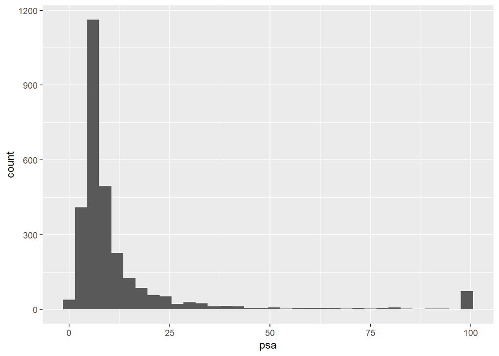

```r
new.d %>%
ggplot( aes(psa)) +
  geom_histogram(binwidth=3)
```

From the histofgram above, the distribution of PSA levels was skewed. So we used log transformation on it in the regression model.

## Model 1 - PSA levels

```r
#model 1 - PSA
model1_PSA<-lm(log(new.d$psa)~new.d$ComorbCat+ new.d$siteid+new.d$ageatdiagnosis+new.d$bmi_cat)
summary(model1_PSA)
```

[output not shown]

## Model 2 - PSA levels

```r
#model 2 - PSA
model2_PSA<-lm(log(new.d$psa)~new.d$ComorbCat+ new.d$siteid+new.d$ageatdiagnosis+new.d$bmi_cat+new.d$smk+new.d$drk)
summary(model2_PSA)
```

[output not shown]

# Models for Clinical stage

For models of clinical stage, we used “glm” function to perform the logistic regression. First, we dichotomized the stage variable. 0 means stage from 0 and T2c and 1 means stage larger than T2c.

- Model 1 (basic model): stage_bin ~ comorbidity + ageatdx + site
- Model 2 (adjusted model): stage_bin ~ comorbidity + ageatdx + site + smoke + drink

```r
#model 1 - stage
clin_stage_bin <- ifelse(new.d$clin_stage > 2.5, 1, 0)
new.d<-data.frame(new.d, clin_stage_bin)

stage_table <- table(new.d$ComorbCat,new.d$clin_stage_bin) # A will be rows, B will be columns
stage_table
```

```
##
##                     0   1
##   Comorbid_0      314  14
##   Comorbid_1      544  19
##   Comorbid_2      684  18
##   Comorbid_3      545  20
##   Comorbid_4_more 650  21
```

## Model 1 - Clinical stage

```r
#model 1 - PSA
model1_stage<-glm(new.d$clin_stage_bin~new.d$ComorbCat+ new.d$siteid+new.d$ageatdiagnosis+new.d$bmi_cat, family="binomial")
summary(model1_stage)
```

```
##
## Call:
## glm(formula = new.d$clin_stage_bin ~ new.d$ComorbCat + new.d$siteid +
##     new.d$ageatdiagnosis + new.d$bmi_cat, family = "binomial")
##
## Deviance Residuals:
##     Min       1Q   Median       3Q      Max
## -0.4957  -0.2777  -0.2380  -0.1991   3.1495
##
## Coefficients:
##                                 Estimate Std. Error z value Pr(>|z|)
## (Intercept)                     -6.61888    1.32714  -4.987 6.12e-07 ***
## new.d$ComorbCatComorbid_1       -0.55178    0.39995  -1.380  0.16770
## new.d$ComorbCatComorbid_2       -0.71389    0.39441  -1.810  0.07029 .
## new.d$ComorbCatComorbid_3       -0.72490    0.41583  -1.743  0.08129 .
## new.d$ComorbCatComorbid_4_more  -0.70511    0.39845  -1.770  0.07679 .
## new.d$siteidGeorgia              0.14688    0.48622   0.302  0.76259
## new.d$siteidNorthern CA          0.39987    0.62041   0.645  0.51924
## new.d$siteidLouisiana            0.20210    0.51915   0.389  0.69706
## new.d$siteidDetroit             -0.06747    0.68294  -0.099  0.92130
## new.d$siteidMichigan           -13.87911  590.15625  -0.024  0.98124
## new.d$siteidLos Angeles County  -0.51071    0.68114  -0.750  0.45339
## new.d$ageatdiagnosis             0.05485    0.01903   2.881  0.00396 **
## new.d$bmi_catoverweight          0.09381    0.34278   0.274  0.78434
## new.d$bmi_catobesity             0.40014    0.34210   1.170  0.24213
## ---
## Signif. codes:  0 '***' 0.001 '**' 0.01 '*' 0.05 '.' 0.1 ' ' 1
##
## (Dispersion parameter for binomial family taken to be 1)
##
##     Null deviance: 643.12  on 2340  degrees of freedom
## Residual deviance: 625.53  on 2327  degrees of freedom
##   (924 observations deleted due to missingness)
## AIC: 653.53
##
## Number of Fisher Scoring iterations: 16
```

```r
exp(cbind(OR=coef(model1_stage), confint.default(model1_stage)))
```

```
##                                          OR        2.5 %     97.5 %
## (Intercept)                    1.334928e-03 9.903638e-05 0.01799371
## new.d$ComorbCatComorbid_1      5.759230e-01 2.629843e-01 1.26124336
## new.d$ComorbCatComorbid_2      4.897353e-01 2.260688e-01 1.06091896
## new.d$ComorbCatComorbid_3      4.843753e-01 2.144009e-01 1.09430259
## new.d$ComorbCatComorbid_4_more 4.940534e-01 2.262618e-01 1.07878925
## new.d$siteidGeorgia            1.158213e+00 4.465984e-01 3.00372363
## new.d$siteidNorthern CA        1.491626e+00 4.421463e-01 5.03215516
## new.d$siteidLouisiana          1.223975e+00 4.424577e-01 3.38589504
## new.d$siteidDetroit            9.347547e-01 2.451175e-01 3.56468308
## new.d$siteidMichigan           9.383801e-07 0.000000e+00        Inf
## new.d$siteidLos Angeles County 6.000712e-01 1.579109e-01 2.28030734
## new.d$ageatdiagnosis           1.056378e+00 1.017694e+00 1.09653280
## new.d$bmi_catoverweight        1.098348e+00 5.609977e-01 2.15039825
## new.d$bmi_catobesity           1.492032e+00 7.631067e-01 2.91723129
```

```r
# model1_stage_null<-glm(new.d$clin_stage_bin~1, family="binomial")
# summary(model1_stage_null)
#
# anova(model1_stage_null,model1_stage,test="LRT" )
```

## Model 2 - Clinical stage

```r
#model 1 - PSA
model2_stage<-glm(new.d$clin_stage_bin~new.d$ComorbCat+ new.d$siteid+new.d$ageatdiagnosis+new.d$bmi_cat+new.d$smk+new.d$drk, family=binomial)
summary(model2_stage)
```

```
##
## Call:
## glm(formula = new.d$clin_stage_bin ~ new.d$ComorbCat + new.d$siteid +
##     new.d$ageatdiagnosis + new.d$bmi_cat + new.d$smk + new.d$drk,
##     family = binomial)
##
## Deviance Residuals:
##     Min       1Q   Median       3Q      Max
## -0.5141  -0.2837  -0.2384  -0.1955   3.0730
##
## Coefficients:
##                                 Estimate Std. Error z value Pr(>|z|)
## (Intercept)                     -6.59779    1.34878  -4.892    1e-06 ***
## new.d$ComorbCatComorbid_1       -0.47692    0.41103  -1.160   0.2459
## new.d$ComorbCatComorbid_2       -0.68474    0.40584  -1.687   0.0916 .
## new.d$ComorbCatComorbid_3       -0.67541    0.42620  -1.585   0.1130
## new.d$ComorbCatComorbid_4_more  -0.69690    0.41177  -1.692   0.0906 .
## new.d$siteidGeorgia              0.10625    0.48786   0.218   0.8276
## new.d$siteidNorthern CA          0.42165    0.62263   0.677   0.4983
## new.d$siteidLouisiana            0.21061    0.52100   0.404   0.6860
## new.d$siteidDetroit             -0.03412    0.68440  -0.050   0.9602
## new.d$siteidMichigan           -13.90386  631.74848  -0.022   0.9824
## new.d$siteidLos Angeles County  -0.55713    0.68221  -0.817   0.4141
## new.d$ageatdiagnosis             0.05431    0.01930   2.814   0.0049 **
## new.d$bmi_catoverweight          0.18485    0.35375   0.523   0.6013
## new.d$bmi_catobesity             0.47181    0.35380   1.334   0.1824
## new.d$smkSmoker                  0.17225    0.24848   0.693   0.4882
## new.d$drkModest                 -0.40969    0.30865  -1.327   0.1844
## new.d$drkHeavy                  -0.25659    0.44592  -0.575   0.5650
## ---
## Signif. codes:  0 '***' 0.001 '**' 0.01 '*' 0.05 '.' 0.1 ' ' 1
##
## (Dispersion parameter for binomial family taken to be 1)
##
##     Null deviance: 629.65  on 2236  degrees of freedom
## Residual deviance: 609.51  on 2220  degrees of freedom
##   (1028 observations deleted due to missingness)
## AIC: 643.51
##
## Number of Fisher Scoring iterations: 16
```

```r
exp(cbind(OR=coef(model2_stage), confint.default(model2_stage)))
```

```
##                                          OR        2.5 %     97.5 %
## (Intercept)                    1.363373e-03 9.694583e-05 0.01917346
## new.d$ComorbCatComorbid_1      6.206894e-01 2.773331e-01 1.38914301
## new.d$ComorbCatComorbid_2      5.042229e-01 2.275973e-01 1.11706397
## new.d$ComorbCatComorbid_3      5.089456e-01 2.207448e-01 1.17341700
## new.d$ComorbCatComorbid_4_more 4.981269e-01 2.222489e-01 1.11645266
## new.d$siteidGeorgia            1.112102e+00 4.274433e-01 2.89341401
## new.d$siteidNorthern CA        1.524470e+00 4.499173e-01 5.16541248
## new.d$siteidLouisiana          1.234433e+00 4.446216e-01 3.42723899
## new.d$siteidDetroit            9.664538e-01 2.527056e-01 3.69613116
## new.d$siteidMichigan           9.154394e-07 0.000000e+00        Inf
## new.d$siteidLos Angeles County 5.728494e-01 1.504328e-01 2.18141501
## new.d$ageatdiagnosis           1.055809e+00 1.016612e+00 1.09651729
## new.d$bmi_catoverweight        1.203035e+00 6.014041e-01 2.40652378
## new.d$bmi_catobesity           1.602899e+00 8.012132e-01 3.20674320
## new.d$smkSmoker                1.187969e+00 7.299562e-01 1.93336302
## new.d$drkModest                6.638566e-01 3.625373e-01 1.21561422
## new.d$drkHeavy                 7.736839e-01 3.228470e-01 1.85408812
```

# Models for Gleason’s score 1

For models of Gleason’s score, we used “glm” function to perform the logistic regression. First, we dichotomized the Gleason’s score variable. 0 means Gleason’s score from 0 and 6 and 1 means Gleason’s score larger than 6. (Cutpoint of 7)

- Model 1 (basic model): G_score_bin1 ~ comorbidity + ageatdx + site
- Model 2 (adjusted model): G_score_bin1 ~ comorbidity + ageatdx + site + smoke + drink

```r
#model 1 - G score
G_score_bin1 <- ifelse(new.d$G_score > 6, 1, 0)
new.d<-data.frame(new.d, G_score_bin1)

G_table1 <- table(new.d$ComorbCat,new.d$G_score_bin1) # A will be rows, B will be columns
G_table1
```

```
##
##                     0   1
##   Comorbid_0      120 252
##   Comorbid_1      209 432
##   Comorbid_2      235 560
##   Comorbid_3      205 431
##   Comorbid_4_more 215 536
```

## Model 1 - Gleason’s score 1

```r
model1_G_score1<- glm(G_score_bin1 ~ new.d$ComorbCat + new.d$siteid+new.d$ageatdiagnosis+new.d$bmi_cat, family=binomial)
summary(model1_G_score1)
```

```
##
## Call:
## glm(formula = G_score_bin1 ~ new.d$ComorbCat + new.d$siteid +
##     new.d$ageatdiagnosis + new.d$bmi_cat, family = binomial)
##
## Deviance Residuals:
##     Min       1Q   Median       3Q      Max
## -1.9759  -1.4263   0.7907   0.8806   1.1837
##
## Coefficients:
##                                 Estimate Std. Error z value Pr(>|z|)
## (Intercept)                    -0.974386   0.433241  -2.249 0.024508 *
## new.d$ComorbCatComorbid_1      -0.084405   0.157028  -0.538 0.590913
## new.d$ComorbCatComorbid_2       0.128571   0.154346   0.833 0.404841
## new.d$ComorbCatComorbid_3      -0.103720   0.159464  -0.650 0.515415
## new.d$ComorbCatComorbid_4_more  0.102800   0.158467   0.649 0.516522
## new.d$siteidGeorgia             0.154432   0.151724   1.018 0.308750
## new.d$siteidNorthern CA        -0.155480   0.213525  -0.728 0.466518
## new.d$siteidLouisiana           0.211677   0.170741   1.240 0.215065
## new.d$siteidDetroit             0.706876   0.242600   2.914 0.003571 **
## new.d$siteidMichigan            0.042645   0.316199   0.135 0.892717
## new.d$siteidLos Angeles County -0.048165   0.185136  -0.260 0.794739
## new.d$ageatdiagnosis            0.023992   0.006411   3.742 0.000182 ***
## new.d$bmi_catoverweight         0.157776   0.114578   1.377 0.168508
## new.d$bmi_catobesity            0.236257   0.118252   1.998 0.045726 *
## ---
## Signif. codes:  0 '***' 0.001 '**' 0.01 '*' 0.05 '.' 0.1 ' ' 1
##
## (Dispersion parameter for binomial family taken to be 1)
##
##     Null deviance: 3256.0  on 2640  degrees of freedom
## Residual deviance: 3217.3  on 2627  degrees of freedom
##   (624 observations deleted due to missingness)
## AIC: 3245.3
##
## Number of Fisher Scoring iterations: 4
```

## Model 2 - Gleason’s score 1

```r
model2_G_score1<- glm(G_score_bin1 ~ new.d$ComorbCat + new.d$siteid+new.d$ageatdiagnosis+new.d$bmi_cat+new.d$smk+new.d$drk, family=binomial)
summary(model2_G_score1)
```

```
##
## Call:
## glm(formula = G_score_bin1 ~ new.d$ComorbCat + new.d$siteid +
##     new.d$ageatdiagnosis + new.d$bmi_cat + new.d$smk + new.d$drk,
##     family = binomial)
##
## Deviance Residuals:
##     Min       1Q   Median       3Q      Max
## -1.9037  -1.4047   0.7832   0.8775   1.2140
##
## Coefficients:
##                                 Estimate Std. Error z value Pr(>|z|)
## (Intercept)                    -0.739020   0.446091  -1.657  0.09759 .
## new.d$ComorbCatComorbid_1      -0.068159   0.161615  -0.422  0.67322
## new.d$ComorbCatComorbid_2       0.119365   0.158443   0.753  0.45123
## new.d$ComorbCatComorbid_3      -0.153208   0.163471  -0.937  0.34864
## new.d$ComorbCatComorbid_4_more  0.084036   0.163196   0.515  0.60659
## new.d$siteidGeorgia             0.134453   0.155480   0.865  0.38717
## new.d$siteidNorthern CA        -0.194353   0.218469  -0.890  0.37367
## new.d$siteidLouisiana           0.165520   0.175210   0.945  0.34481
## new.d$siteidDetroit             0.612715   0.246072   2.490  0.01277 *
## new.d$siteidMichigan            0.016148   0.333232   0.048  0.96135
## new.d$siteidLos Angeles County -0.109360   0.188564  -0.580  0.56194
## new.d$ageatdiagnosis            0.021524   0.006595   3.264  0.00110 **
## new.d$bmi_catoverweight         0.198115   0.118005   1.679  0.09318 .
## new.d$bmi_catobesity            0.255505   0.121930   2.096  0.03613 *
## new.d$smkSmoker                 0.061892   0.089923   0.688  0.49128
## new.d$drkModest                -0.261706   0.098886  -2.647  0.00813 **
## new.d$drkHeavy                 -0.171941   0.150463  -1.143  0.25314
## ---
## Signif. codes:  0 '***' 0.001 '**' 0.01 '*' 0.05 '.' 0.1 ' ' 1
##
## (Dispersion parameter for binomial family taken to be 1)
##
##     Null deviance: 3116.3  on 2525  degrees of freedom
## Residual deviance: 3072.1  on 2509  degrees of freedom
##   (739 observations deleted due to missingness)
## AIC: 3106.1
##
## Number of Fisher Scoring iterations: 4
```

# Models for Gleason’s score 2

For models of Gleason’s score, we used “glm” function to perform the logistic regression. First, we dichotomized the Gleason’s score variable. 0 means Gleason’s score from 0 and 7 and 1 means Gleason’s score larger than 7. (Cutpoint of 8)

- Model 1 (basic model): G_score_bin2 ~ comorbidity + ageatdx + site
- Model 2 (adjusted model): G_score_bin2 ~ comorbidity + ageatdx + site + smoke + drink

```r
#model 1 - G score
G_score_bin2 <- ifelse(new.d$G_score > 7, 1, 0)
new.d<-data.frame(new.d, G_score_bin2)

G_table2 <- table(new.d$ComorbCat,new.d$G_score_bin2) # A will be rows, B will be columns
G_table2
```

```
##
##                     0   1
##   Comorbid_0      290  82
##   Comorbid_1      500 141
##   Comorbid_2      611 184
##   Comorbid_3      514 122
##   Comorbid_4_more 581 170
```

## Model 1 - Gleason’s score 2

```r
model1_G_score1<- glm(G_score_bin2 ~ new.d$ComorbCat + new.d$siteid+new.d$ageatdiagnosis+new.d$bmi_cat, family=binomial)
summary(model1_G_score1)
```

```
##
## Call:
## glm(formula = G_score_bin2 ~ new.d$ComorbCat + new.d$siteid +
##     new.d$ageatdiagnosis + new.d$bmi_cat, family = binomial)
##
## Deviance Residuals:
##     Min       1Q   Median       3Q      Max
## -1.0276  -0.7409  -0.6609  -0.4766   2.7851
##
## Coefficients:
##                                 Estimate Std. Error z value Pr(>|z|)
## (Intercept)                    -3.236760   0.506638  -6.389 1.67e-10 ***
## new.d$ComorbCatComorbid_1      -0.044735   0.180685  -0.248  0.80445
## new.d$ComorbCatComorbid_2       0.073586   0.173459   0.424  0.67140
## new.d$ComorbCatComorbid_3      -0.260954   0.186653  -1.398  0.16209
## new.d$ComorbCatComorbid_4_more -0.052164   0.178186  -0.293  0.76971
## new.d$siteidGeorgia            -0.064978   0.170508  -0.381  0.70314
## new.d$siteidNorthern CA        -0.746201   0.281980  -2.646  0.00814 **
## new.d$siteidLouisiana           0.084070   0.187855   0.448  0.65450
## new.d$siteidDetroit            -0.025952   0.248147  -0.105  0.91671
## new.d$siteidMichigan           -2.760423   1.021563  -2.702  0.00689 **
## new.d$siteidLos Angeles County -0.201255   0.213930  -0.941  0.34683
## new.d$ageatdiagnosis            0.033608   0.007413   4.534 5.80e-06 ***
## new.d$bmi_catoverweight        -0.065685   0.130169  -0.505  0.61383
## new.d$bmi_catobesity            0.060980   0.132936   0.459  0.64644
## ---
## Signif. codes:  0 '***' 0.001 '**' 0.01 '*' 0.05 '.' 0.1 ' ' 1
##
## (Dispersion parameter for binomial family taken to be 1)
##
##     Null deviance: 2752.4  on 2640  degrees of freedom
## Residual deviance: 2693.1  on 2627  degrees of freedom
##   (624 observations deleted due to missingness)
## AIC: 2721.1
##
## Number of Fisher Scoring iterations: 6
```

```r
exp(cbind(OR=coef(model1_G_score1), confint.default(model1_G_score1)))
```

```
##                                        OR       2.5 %    97.5 %
## (Intercept)                    0.03929101 0.014555990 0.1060583
## new.d$ComorbCatComorbid_1      0.95625076 0.671077786 1.3626073
## new.d$ComorbCatComorbid_2      1.07636093 0.766141442 1.5121919
## new.d$ComorbCatComorbid_3      0.77031601 0.534305096 1.1105766
## new.d$ComorbCatComorbid_4_more 0.94917308 0.669380844 1.3459147
## new.d$siteidGeorgia            0.93708784 0.670878046 1.3089318
## new.d$siteidNorthern CA        0.47416437 0.272839564 0.8240442
## new.d$siteidLouisiana          1.08770487 0.752676532 1.5718597
## new.d$siteidDetroit            0.97438201 0.599109519 1.5847191
## new.d$siteidMichigan           0.06326498 0.008542947 0.4685101
## new.d$siteidLos Angeles County 0.81770412 0.537648765 1.2436372
## new.d$ageatdiagnosis           1.03417912 1.019261911 1.0493146
## new.d$bmi_catoverweight        0.93642545 0.725560018 1.2085735
## new.d$bmi_catobesity           1.06287739 0.819082172 1.3792369
```

## Model 2 - Gleason’s score 2

```r
model2_G_score1<- glm(G_score_bin2 ~ new.d$ComorbCat + new.d$siteid+new.d$ageatdiagnosis+new.d$bmi_cat+new.d$smk+new.d$drk, family=binomial)
summary(model2_G_score1)
```

```
##
## Call:
## glm(formula = G_score_bin2 ~ new.d$ComorbCat + new.d$siteid +
##     new.d$ageatdiagnosis + new.d$bmi_cat + new.d$smk + new.d$drk,
##     family = binomial)
##
## Deviance Residuals:
##     Min       1Q   Median       3Q      Max
## -1.0355  -0.7404  -0.6568  -0.4776   2.2840
##
## Coefficients:
##                                  Estimate Std. Error z value Pr(>|z|)
## (Intercept)                     -3.203924   0.523506  -6.120 9.35e-10 ***
## new.d$ComorbCatComorbid_1       -0.002118   0.186830  -0.011    0.991
## new.d$ComorbCatComorbid_2        0.088814   0.179576   0.495    0.621
## new.d$ComorbCatComorbid_3       -0.246923   0.193404  -1.277    0.202
## new.d$ComorbCatComorbid_4_more   0.001506   0.184593   0.008    0.993
## new.d$siteidGeorgia             -0.056800   0.173981  -0.326    0.744
## new.d$siteidNorthern CA         -0.679066   0.284605  -2.386    0.017 *
## new.d$siteidLouisiana            0.073612   0.192648   0.382    0.702
## new.d$siteidDetroit             -0.092418   0.258303  -0.358    0.721
## new.d$siteidMichigan           -15.285694 336.506164  -0.045    0.964
## new.d$siteidLos Angeles County  -0.196886   0.217245  -0.906    0.365
## new.d$ageatdiagnosis             0.032607   0.007639   4.268 1.97e-05 ***
## new.d$bmi_catoverweight          0.046849   0.136119   0.344    0.731
## new.d$bmi_catobesity             0.128050   0.139554   0.918    0.359
## new.d$smkSmoker                 -0.005773   0.100793  -0.057    0.954
## new.d$drkModest                 -0.194207   0.115978  -1.675    0.094 .
## new.d$drkHeavy                  -0.208382   0.179147  -1.163    0.245
## ---
## Signif. codes:  0 '***' 0.001 '**' 0.01 '*' 0.05 '.' 0.1 ' ' 1
##
## (Dispersion parameter for binomial family taken to be 1)
##
##     Null deviance: 2629.4  on 2525  degrees of freedom
## Residual deviance: 2564.9  on 2509  degrees of freedom
##   (739 observations deleted due to missingness)
## AIC: 2598.9
##
## Number of Fisher Scoring iterations: 15
```

```r
exp(cbind(OR=coef(model2_G_score1), confint.default(model2_G_score1)))
```

```
##                                          OR         2.5 %        97.5 %
## (Intercept)                    4.060258e-02  1.455273e-02  1.132825e-01
## new.d$ComorbCatComorbid_1      9.978847e-01  6.919116e-01  1.439164e+00
## new.d$ComorbCatComorbid_2      1.092877e+00  7.686277e-01  1.553912e+00
## new.d$ComorbCatComorbid_3      7.812010e-01  5.347332e-01  1.141270e+00
## new.d$ComorbCatComorbid_4_more 1.001507e+00  6.974734e-01  1.438070e+00
## new.d$siteidGeorgia            9.447834e-01  6.717989e-01  1.328695e+00
## new.d$siteidNorthern CA        5.070906e-01  2.902881e-01  8.858126e-01
## new.d$siteidLouisiana          1.076389e+00  7.378824e-01  1.570188e+00
## new.d$siteidDetroit            9.117241e-01  5.495348e-01  1.512626e+00
## new.d$siteidMichigan           2.298834e-07 8.451645e-294 6.252793e+279
## new.d$siteidLos Angeles County 8.212844e-01  5.365061e-01  1.257224e+00
## new.d$ageatdiagnosis           1.033145e+00  1.017791e+00  1.048730e+00
## new.d$bmi_catoverweight        1.047964e+00  8.025668e-01  1.368394e+00
## new.d$bmi_catobesity           1.136609e+00  8.646140e-01  1.494171e+00
## new.d$smkSmoker                9.942440e-01  8.160142e-01  1.211402e+00
## new.d$drkModest                8.234870e-01  6.560487e-01  1.033659e+00
## new.d$drkHeavy                 8.118970e-01  5.714932e-01  1.153429e+00
```

# Aggressiveness

- Model 1 (basic model): aggre_bin ~ comorbidity + ageatdx + site
- Model 2 (adjusted model): aggre_bin ~ comorbidity + ageatdx + site + smoke + drink

Then, we conducted a multinomial regression model for the multiple categorical outcomes.

```r
aggressiveness_bin <- ifelse(new.d$aggre > 2, 1, 0)
new.d<-data.frame(new.d, aggressiveness_bin)

aggre_bin <- table(new.d$ComorbCat,new.d$aggressiveness_bin) # A will be rows, B will be columns
aggre_bin
```

```
##
##                     0   1
##   Comorbid_0      250 125
##   Comorbid_1      443 201
##   Comorbid_2      552 245
##   Comorbid_3      455 183
##   Comorbid_4_more 529 223
```

## Model 1 - Aggressiveness

```r
model1_Aggressiveness<- glm(aggressiveness_bin ~ new.d$ComorbCat + new.d$siteid+new.d$ageatdiagnosis+new.d$bmi_cat, family=binomial)
summary(model1_Aggressiveness)
```

```
##
## Call:
## glm(formula = aggressiveness_bin ~ new.d$ComorbCat + new.d$siteid +
##     new.d$ageatdiagnosis + new.d$bmi_cat, family = binomial)
##
## Deviance Residuals:
##     Min       1Q   Median       3Q      Max
## -1.0955  -0.8669  -0.7904   1.4356   2.2539
##
## Coefficients:
##                                 Estimate Std. Error z value Pr(>|z|)
## (Intercept)                    -1.873682   0.444417  -4.216 2.49e-05 ***
## new.d$ComorbCatComorbid_1      -0.045140   0.159046  -0.284 0.776548
## new.d$ComorbCatComorbid_2      -0.046501   0.154349  -0.301 0.763207
## new.d$ComorbCatComorbid_3      -0.246851   0.163580  -1.509 0.131283
## new.d$ComorbCatComorbid_4_more -0.157501   0.158601  -0.993 0.320677
## new.d$siteidGeorgia            -0.236088   0.151772  -1.556 0.119815
## new.d$siteidNorthern CA        -0.436414   0.226654  -1.925 0.054171 .
## new.d$siteidLouisiana          -0.085480   0.168706  -0.507 0.612378
## new.d$siteidDetroit            -0.095431   0.220583  -0.433 0.665285
## new.d$siteidMichigan           -1.460354   0.454155  -3.216 0.001302 **
## new.d$siteidLos Angeles County -0.234275   0.188709  -1.241 0.214434
## new.d$ageatdiagnosis            0.022911   0.006555   3.495 0.000473 ***
## new.d$bmi_catoverweight        -0.228808   0.115733  -1.977 0.048038 *
## new.d$bmi_catobesity           -0.027621   0.117722  -0.235 0.814498
## ---
## Signif. codes:  0 '***' 0.001 '**' 0.01 '*' 0.05 '.' 0.1 ' ' 1
##
## (Dispersion parameter for binomial family taken to be 1)
##
##     Null deviance: 3222.2  on 2649  degrees of freedom
## Residual deviance: 3184.0  on 2636  degrees of freedom
##   (615 observations deleted due to missingness)
## AIC: 3212
##
## Number of Fisher Scoring iterations: 4
```

## Model 2 - Aggressiveness

```r
model2_Aggressiveness<- glm(aggressiveness_bin ~ new.d$ComorbCat + new.d$siteid+new.d$ageatdiagnosis+new.d$bmi_cat+new.d$smk+new.d$drk, family=binomial)
summary(model2_Aggressiveness)
```

```
##
## Call:
## glm(formula = aggressiveness_bin ~ new.d$ComorbCat + new.d$siteid +
##     new.d$ageatdiagnosis + new.d$bmi_cat + new.d$smk + new.d$drk,
##     family = binomial)
##
## Deviance Residuals:
##     Min       1Q   Median       3Q      Max
## -1.1132  -0.8701  -0.7913   1.4295   2.2092
##
## Coefficients:
##                                 Estimate Std. Error z value Pr(>|z|)
## (Intercept)                    -1.777744   0.457351  -3.887 0.000101 ***
## new.d$ComorbCatComorbid_1       0.010307   0.164046   0.063 0.949903
## new.d$ComorbCatComorbid_2      -0.022580   0.159154  -0.142 0.887177
## new.d$ComorbCatComorbid_3      -0.202949   0.168584  -1.204 0.228649
## new.d$ComorbCatComorbid_4_more -0.103837   0.163684  -0.634 0.525836
## new.d$siteidGeorgia            -0.249801   0.154447  -1.617 0.105795
## new.d$siteidNorthern CA        -0.413174   0.230491  -1.793 0.073041 .
## new.d$siteidLouisiana          -0.113024   0.172482  -0.655 0.512289
## new.d$siteidDetroit            -0.138285   0.227070  -0.609 0.542527
## new.d$siteidMichigan           -1.551789   0.492544  -3.151 0.001630 **
## new.d$siteidLos Angeles County -0.244215   0.191212  -1.277 0.201533
## new.d$ageatdiagnosis            0.020888   0.006735   3.101 0.001927 **
## new.d$bmi_catoverweight        -0.144735   0.119803  -1.208 0.227004
## new.d$bmi_catobesity            0.014517   0.122277   0.119 0.905496
## new.d$smkSmoker                 0.095740   0.090042   1.063 0.287653
## new.d$drkModest                -0.219688   0.102982  -2.133 0.032903 *
## new.d$drkHeavy                 -0.271308   0.158811  -1.708 0.087568 .
## ---
## Signif. codes:  0 '***' 0.001 '**' 0.01 '*' 0.05 '.' 0.1 ' ' 1
##
## (Dispersion parameter for binomial family taken to be 1)
##
##     Null deviance: 3087.7  on 2534  degrees of freedom
## Residual deviance: 3047.1  on 2518  degrees of freedom
##   (730 observations deleted due to missingness)
## AIC: 3081.1
##
## Number of Fisher Scoring iterations: 4
```

## Model 3 - Aggressiveness

```r
model3_Aggressiveness<-multinom (aggre ~ new.d$ComorbCat +new.d$siteid+new.d$ageatdiagnosis+new.d$bmi_cat)
summary(model3_Aggressiveness)
```

```
## Call:
## multinom(formula = aggre ~ new.d$ComorbCat + new.d$siteid + new.d$ageatdiagnosis +
##     new.d$bmi_cat)
##
## Coefficients:
##   (Intercept) new.d$ComorbCatComorbid_1 new.d$ComorbCatComorbid_2
## 2   -1.073110                -0.2214800               -0.06823969
## 3   -1.899186                -0.1879045               -0.09202554
##   new.d$ComorbCatComorbid_3 new.d$ComorbCatComorbid_4_more new.d$siteidGeorgia
## 2                -0.1865164                    -0.03195915          0.26236024
## 3                -0.3681157                    -0.17886088         -0.07514075
##   new.d$siteidNorthern CA new.d$siteidLouisiana new.d$siteidDetroit
## 2              0.05189001            0.28085471           0.8995523
## 3             -0.40615155            0.08780029           0.5172219
##   new.d$siteidMichigan new.d$siteidLos Angeles County new.d$ageatdiagnosis
## 2            0.4296719                      0.2044630           0.02096769
## 3           -1.1896254                     -0.1102124           0.03641046
##   new.d$bmi_catoverweight new.d$bmi_catobesity
## 2              0.26965604            0.2573676
## 3             -0.05716276            0.1361046
##
## Std. Errors:
##   (Intercept) new.d$ComorbCatComorbid_1 new.d$ComorbCatComorbid_2
## 2   0.4957119                 0.1837010                 0.1796260
## 3   0.5435434                 0.1978961                 0.1938401
##   new.d$ComorbCatComorbid_3 new.d$ComorbCatComorbid_4_more new.d$siteidGeorgia
## 2                 0.1852579                      0.1842044           0.1770687
## 3                 0.2026774                      0.1996172           0.1845163
##   new.d$siteidNorthern CA new.d$siteidLouisiana new.d$siteidDetroit
## 2               0.2457258             0.1990966           0.2810276
## 3               0.2691251             0.2074556           0.2977243
##   new.d$siteidMichigan new.d$siteidLos Angeles County new.d$ageatdiagnosis
## 2            0.3403108                      0.2164337          0.007307474
## 3            0.5051854                      0.2297086          0.008067912
##   new.d$bmi_catoverweight new.d$bmi_catobesity
## 2               0.1321155            0.1364531
## 3               0.1420218            0.1452872
##
## Residual Deviance: 5589.633
## AIC: 5645.633
```

```r
z <- summary(model3_Aggressiveness)$coefficients/summary(model3_Aggressiveness)$standard.errors
# 2-tailed Wald z tests to test significance of coefficients
p <- (1 - pnorm(abs(z), 0, 1)) * 2
print("p values")
```

```
## [1] "p values"
```

```r
p
```

```
##    (Intercept) new.d$ComorbCatComorbid_1 new.d$ComorbCatComorbid_2
## 2 0.0304040579                 0.2279507                 0.7040206
## 3 0.0004756935                 0.3423609                 0.6349654
##   new.d$ComorbCatComorbid_3 new.d$ComorbCatComorbid_4_more new.d$siteidGeorgia
## 2                0.31403407                      0.8622598           0.1384239
## 3                0.06932984                      0.3702424           0.6838384
##   new.d$siteidNorthern CA new.d$siteidLouisiana new.d$siteidDetroit
## 2               0.8327543             0.1583491         0.001369801
## 3               0.1312591             0.6721314         0.082342822
##   new.d$siteidMichigan new.d$siteidLos Angeles County new.d$ageatdiagnosis
## 2           0.20673773                      0.3448166         4.113181e-03
## 3           0.01853122                      0.6313750         6.391811e-06
##   new.d$bmi_catoverweight new.d$bmi_catobesity
## 2              0.04124454           0.05927812
## 3              0.68732143           0.34886309
```

```r
exp(summary(model3_Aggressiveness)$coefficients)
```

```
##   (Intercept) new.d$ComorbCatComorbid_1 new.d$ComorbCatComorbid_2
## 2   0.3419433                 0.8013320                 0.9340366
## 3   0.1496905                 0.8286939                 0.9120819
##   new.d$ComorbCatComorbid_3 new.d$ComorbCatComorbid_4_more new.d$siteidGeorgia
## 2                 0.8298450                      0.9685461           1.2999948
## 3                 0.6920371                      0.8362222           0.9276129
##   new.d$siteidNorthern CA new.d$siteidLouisiana new.d$siteidDetroit
## 2               1.0532599              1.324261            2.458502
## 3               0.6662092              1.091770            1.677361
##   new.d$siteidMichigan new.d$siteidLos Angeles County new.d$ageatdiagnosis
## 2            1.5367533                      1.2268661             1.021189
## 3            0.3043352                      0.8956439             1.037081
##   new.d$bmi_catoverweight new.d$bmi_catobesity
## 2               1.3095140             1.293521
## 3               0.9444403             1.145802
```

```r
exp(confint(model3_Aggressiveness))
```

```
## , , 2
##
##                                    2.5 %    97.5 %
## (Intercept)                    0.1294206 0.9034515
## new.d$ComorbCatComorbid_1      0.5590438 1.1486271
## new.d$ComorbCatComorbid_2      0.6568496 1.3281949
## new.d$ComorbCatComorbid_3      0.5771719 1.1931327
## new.d$ComorbCatComorbid_4_more 0.6750333 1.3896820
## new.d$siteidGeorgia            0.9187988 1.8393432
## new.d$siteidNorthern CA        0.6506889 1.7048952
## new.d$siteidLouisiana          0.8964010 1.9563428
## new.d$siteidDetroit            1.4172926 4.2646333
## new.d$siteidMichigan           0.7887349 2.9941754
## new.d$siteidLos Angeles County 0.8027281 1.8751063
## new.d$ageatdiagnosis           1.0066674 1.0359202
## new.d$bmi_catoverweight        1.0107721 1.6965514
## new.d$bmi_catobesity           0.9899750 1.6901389
##
## , , 3
##
##                                     2.5 %    97.5 %
## (Intercept)                    0.05158569 0.4343693
## new.d$ComorbCatComorbid_1      0.56226968 1.2213597
## new.d$ComorbCatComorbid_2      0.62378769 1.3336161
## new.d$ComorbCatComorbid_3      0.46516823 1.0295530
## new.d$ComorbCatComorbid_4_more 0.56546695 1.2366198
## new.d$siteidGeorgia            0.64610966 1.3317642
## new.d$siteidNorthern CA        0.39312523 1.1289906
## new.d$siteidLouisiana          0.72701719 1.6395236
## new.d$siteidDetroit            0.93584355 3.0064222
## new.d$siteidMichigan           0.11306746 0.8191564
## new.d$siteidLos Angeles County 0.57096182 1.4049590
## new.d$ageatdiagnosis           1.02081124 1.0536110
## new.d$bmi_catoverweight        0.71496590 1.2475666
## new.d$bmi_catobesity           0.86186803 1.5232746
```

## Model 4 - Aggressiveness

```r
model4_Aggressiveness<-multinom (aggre ~ new.d$ComorbCat +new.d$siteid+new.d$ageatdiagnosis+new.d$bmi_cat+new.d$smk+new.d$drk)
summary(model4_Aggressiveness)
```

```
## Call:
## multinom(formula = aggre ~ new.d$ComorbCat + new.d$siteid + new.d$ageatdiagnosis +
##     new.d$bmi_cat + new.d$smk + new.d$drk)
##
## Coefficients:
##   (Intercept) new.d$ComorbCatComorbid_1 new.d$ComorbCatComorbid_2
## 2  -0.7070969                -0.2299917               -0.09637131
## 3  -1.5704199                -0.1390473               -0.08635833
##   new.d$ComorbCatComorbid_3 new.d$ComorbCatComorbid_4_more new.d$siteidGeorgia
## 2                -0.2676526                    -0.07543689           0.2296826
## 3                -0.3761285                    -0.15332247          -0.1070616
##   new.d$siteidNorthern CA new.d$siteidLouisiana new.d$siteidDetroit
## 2             -0.03861255            0.20809108           0.7936884
## 3             -0.43634543            0.01596566           0.4015328
##   new.d$siteidMichigan new.d$siteidLos Angeles County new.d$ageatdiagnosis
## 2            0.4093164                      0.1242691           0.01708078
## 3           -1.2895804                     -0.1689091           0.03189664
##   new.d$bmi_catoverweight new.d$bmi_catobesity new.d$smkSmoker new.d$drkModest
## 2              0.28737335            0.2455104      0.08855325      -0.2407118
## 3              0.03911394            0.1708491      0.15268569      -0.3726260
##   new.d$drkHeavy
## 2     -0.1616923
## 3     -0.3750974
##
## Std. Errors:
##   (Intercept) new.d$ComorbCatComorbid_1 new.d$ComorbCatComorbid_2
## 2   0.5104403                 0.1886592                 0.1839082
## 3   0.5605062                 0.2046218                 0.2001554
##   new.d$ComorbCatComorbid_3 new.d$ComorbCatComorbid_4_more new.d$siteidGeorgia
## 2                 0.1896047                       0.189468           0.1815330
## 3                 0.2086764                       0.206468           0.1894464
##   new.d$siteidNorthern CA new.d$siteidLouisiana new.d$siteidDetroit
## 2               0.2514729             0.2041851           0.2849267
## 3               0.2742439             0.2131540           0.3034511
##   new.d$siteidMichigan new.d$siteidLos Angeles County new.d$ageatdiagnosis
## 2            0.3583333                      0.2206939          0.007518196
## 3            0.5466622                      0.2338813          0.008297460
##   new.d$bmi_catoverweight new.d$bmi_catobesity new.d$smkSmoker new.d$drkModest
## 2               0.1358739            0.1403773       0.1027647       0.1126605
## 3               0.1468556            0.1504326       0.1119886       0.1248000
##   new.d$drkHeavy
## 2      0.1700056
## 3      0.1912224
##
## Residual Deviance: 5341.933
## AIC: 5409.933
```

```r
z <- summary(model4_Aggressiveness)$coefficients/summary(model4_Aggressiveness)$standard.errors
# 2-tailed Wald z tests to test significance of coefficients
p <- (1 - pnorm(abs(z), 0, 1)) * 2
print("p values")
```

```
## [1] "p values"
```

```r
p
```

```
##   (Intercept) new.d$ComorbCatComorbid_1 new.d$ComorbCatComorbid_2
## 2 0.165970364                 0.2228116                 0.6002657
## 3 0.005082015                 0.4968001                 0.6661365
##   new.d$ComorbCatComorbid_3 new.d$ComorbCatComorbid_4_more new.d$siteidGeorgia
## 2                0.15805755                      0.6905189           0.2057856
## 3                0.07147484                      0.4577259           0.5719863
##   new.d$siteidNorthern CA new.d$siteidLouisiana new.d$siteidDetroit
## 2               0.8779681             0.3081415         0.005343077
## 3               0.1115904             0.9402927         0.185761948
##   new.d$siteidMichigan new.d$siteidLos Angeles County new.d$ageatdiagnosis
## 2           0.25333832                      0.5733779         0.0230910550
## 3           0.01832388                      0.4701714         0.0001209734
##   new.d$bmi_catoverweight new.d$bmi_catobesity new.d$smkSmoker new.d$drkModest
## 2              0.03442994           0.08030268       0.3888480     0.032629497
## 3              0.78997517           0.25607440       0.1727553     0.002828517
##   new.d$drkHeavy
## 2     0.34155376
## 3     0.04981178
```

```r
exp(summary(model4_Aggressiveness)$coefficients)
```

```
##   (Intercept) new.d$ComorbCatComorbid_1 new.d$ComorbCatComorbid_2
## 2   0.4930736                 0.7945402                 0.9081268
## 3   0.2079578                 0.8701869                 0.9172655
##   new.d$ComorbCatComorbid_3 new.d$ComorbCatComorbid_4_more new.d$siteidGeorgia
## 2                 0.7651736                      0.9273383           1.2582006
## 3                 0.6865141                      0.8578530           0.8984704
##   new.d$siteidNorthern CA new.d$siteidLouisiana new.d$siteidDetroit
## 2               0.9621234              1.231325            2.211538
## 3               0.6463944              1.016094            1.494113
##   new.d$siteidMichigan new.d$siteidLos Angeles County new.d$ageatdiagnosis
## 2            1.5057881                      1.1323206             1.017227
## 3            0.2753863                      0.8445857             1.032411
##   new.d$bmi_catoverweight new.d$bmi_catobesity new.d$smkSmoker new.d$drkModest
## 2                1.332922             1.278274        1.092592       0.7860681
## 3                1.039889             1.186312        1.164959       0.6889228
##   new.d$drkHeavy
## 2      0.8507029
## 3      0.6872223
```

```r
exp(confint(model4_Aggressiveness))
```

```
## , , 2
##
##                                    2.5 %    97.5 %
## (Intercept)                    0.1813110 1.3409089
## new.d$ComorbCatComorbid_1      0.5489450 1.1500133
## new.d$ComorbCatComorbid_2      0.6332912 1.3022353
## new.d$ComorbCatComorbid_3      0.5276770 1.1095625
## new.d$ComorbCatComorbid_4_more 0.6396799 1.3443540
## new.d$siteidGeorgia            0.8815131 1.7958540
## new.d$siteidNorthern CA        0.5877284 1.5750158
## new.d$siteidLouisiana          0.8252207 1.8372806
## new.d$siteidDetroit            1.2652153 3.8656678
## new.d$siteidMichigan           0.7460192 3.0393292
## new.d$siteidLos Angeles County 0.7347074 1.7451164
## new.d$ageatdiagnosis           1.0023481 1.0323277
## new.d$bmi_catoverweight        1.0212888 1.7396455
## new.d$bmi_catobesity           0.9708105 1.6831127
## new.d$smkSmoker                0.8932740 1.3363853
## new.d$drkModest                0.6303233 0.9802954
## new.d$drkHeavy                 0.6096335 1.1870991
##
## , , 3
##
##                                     2.5 %    97.5 %
## (Intercept)                    0.06932208 0.6238483
## new.d$ComorbCatComorbid_1      0.58269079 1.2995318
## new.d$ComorbCatComorbid_2      0.61961582 1.3578995
## new.d$ComorbCatComorbid_3      0.45606190 1.0334159
## new.d$ComorbCatComorbid_4_more 0.57235699 1.2857567
## new.d$siteidGeorgia            0.61979305 1.3024492
## new.d$siteidNorthern CA        0.37762499 1.1064568
## new.d$siteidLouisiana          0.66910889 1.5430173
## new.d$siteidDetroit            0.82430029 2.7082047
## new.d$siteidMichigan           0.09432408 0.8040112
## new.d$siteidLos Angeles County 0.53402747 1.3357458
## new.d$ageatdiagnosis           1.01575677 1.0493379
## new.d$bmi_catoverweight        0.77980006 1.3867260
## new.d$bmi_catobesity           0.88338569 1.5931155
## new.d$smkSmoker                0.93537481 1.4508932
## new.d$drkModest                0.53943681 0.8798336
## new.d$drkHeavy                 0.47242020 0.9996916
```